# Multisite bacterial community analysis

Sarah R. Johnston

16 March 2017

## Load the requisite packages

```r
library(doParallel)
library(dplyr)
```

```r
library(ggplot2)
library(metacoder)
library(vegan)
```

Multiplot function for ggplot graphics (from http://www.cookbook-r.com/Graphs/Multiple_graphs_on_one_page_(ggplot2)/)

```r
multiplot <- function(..., plotlist=NULL, file, cols=1, layout=NULL) {
  library(grid)

  # Make a list from the ... arguments and plotlist
  plots <- c(list(...), plotlist)

  numPlots = length(plots)

  # If layout is NULL, then use 'cols' to determine layout
  if (is.null(layout)) {
    # Make the panel
    # ncol: Number of columns of plots
    # nrow: Number of rows needed, calculated from # of cols
    layout <- matrix(seq(1, cols * ceiling(numPlots/cols)),
                     ncol = cols, nrow = ceiling(numPlots/cols))
  }

  if (numPlots==1) {
    print(plots[[1]])

  } else {
    # Set up the page
    grid.newpage()
    pushViewport(viewport(layout = grid.layout(nrow(layout), ncol(layout))))

    # Make each plot, in the correct location
    for (i in 1:numPlots) {
      # Get the i,j matrix positions of the regions that contain this subplot
      matchidx <- as.data.frame(which(layout == i, arr.ind = TRUE))

      print(plots[[i]], vp = viewport(layout.pos.row = matchidx$row,
                                      layout.pos.col = matchidx$col))
    }
  }
}
```

## Prepare the data for analysis

### Bacterial data preparation

Load in the bacterial OTU table.This is a .csv with samples as columns, OTUs as rows. The first column is a list of OTU IDs, and the column headers are sample names. There is also a file of sample metadata (the mapping file used in QIIME pre-processing, with additional columns added containing the soil and wood pH data).

```r
#Read in OTUs
msbact1<-read.csv('multisite_gg_otu_table_exp-only.csv', header = TRUE)
#Read in metadata
metadat<-read.csv('multisite_map_pH_reiso_exp-only.csv', header = TRUE)

#Make the samples rows and OTUs columns
#Need to exclude the first column (OTU IDs) and then add it in a column names on new dframe
#Otherwise R will make the OTU IDs the first row, and set every column as factors
msbact2<-as.data.frame(t(msbact1[,-1]))
colnames(msbact2) <- msbact1$X.OTU.ID
summary(msbact2[,1:5])
```

```
##      378462            276627           241214            149938
##  Min.   :0.00000   Min.   :0.0000   Min.   :0.00000   Min.   :  0.00
##  1st Qu.:0.00000   1st Qu.:0.0000   1st Qu.:0.00000   1st Qu.:  0.00
##  Median :0.00000   Median :0.0000   Median :0.00000   Median :  1.00
##  Mean   :0.03261   Mean   :0.1087   Mean   :0.05435   Mean   : 10.74
##  3rd Qu.:0.00000   3rd Qu.:0.0000   3rd Qu.:0.00000   3rd Qu.:  5.25
##  Max.   :2.00000   Max.   :6.0000   Max.   :2.00000   Max.   :127.00
##      250428
##  Min.   :0.00000
##  1st Qu.:0.00000
##  Median :0.00000
##  Mean   :0.03261
##  3rd Qu.:0.00000
##  Max.   :2.00000
```

```r
summary(msbact1[,1:5])
```

```
##     X.OTU.ID          B7               WyF                WS13
##  100054 :   1   Min.   :   0.00   Min.   :  0.0000   Min.   :   0.000
##  100060 :   1   1st Qu.:   0.00   1st Qu.:  0.0000   1st Qu.:   0.000
##  100174 :   1   Median :   0.00   Median :  0.0000   Median :   0.000
##  100307 :   1   Mean   :   5.37   Mean   :  0.5764   Mean   :   3.222
##  100442 :   1   3rd Qu.:   0.00   3rd Qu.:  0.0000   3rd Qu.:   0.000
##  100505 :   1   Max.   :6320.00   Max.   :611.0000   Max.   :1596.000
##  (Other):7567
##       G14
##  Min.   :   0.00
##  1st Qu.:   0.00
##  Median :   0.00
##  Mean   :   5.75
##  3rd Qu.:   0.00
##  Max.   :4722.00
##
```

```r
#Remove sample 1339 (T10), which is of uncertain identity
msbact2<-subset(msbact2, !rownames(msbact2)=="T10")
metadat<-subset(metadat, !metadat$X.SampleID=="T10")
#Remove columns with zero sums (created by removing some samples from the OTU table at an earlier stage)
msbact2<-msbact2[,(!colSums(msbact2)==0)]

#Check that the samples are in the same order in the OTU and metadata tables
#Save sample ID as an object (currently stored as OTU row names)
Sample.ID<-rownames(msbact2)
#Check the order
metchar<-as.character(metadat$X.SampleID)
all.equal(Sample.ID, metchar)
```

```
## [1] "89 string mismatches"
```

```r
#Sort both data frames to correct this
metadat<-metadat[order(metadat$X.SampleID),]
msbact<-msbact2[order(Sample.ID),]
#Check again
metchar<-as.character(metadat$X.SampleID)
all.equal(rownames(msbact), metchar)
```

```
## [1] TRUE
```

```r
#Calculate proportions
bactprops<-msbact/rowSums(msbact)

#Calculate the sequencing depth for bacterial samples
depth<-(rowSums(msbact))
#Convert it to a value between 0-255, for later use in plotting
max(depth)/255 #=277.7
```

```
## [1] 277.702
```

```r
grad<-depth/278

#Calculate the OTU richness for bacterial samples
richness<-rowSums(msbact>0) #Counts the number of occurrances for each OTU (because TRUE=1, FALSE=0)

#Read in an additional copy of the OTU table with additional columns covering taxonomy. This will be used to subsequently match taxonomic information to the OTU identity.
taxbact1<-read.csv('multisite_gg_otu_table_exp-only_with_taxonomy.csv', header = TRUE)
taxbact<-taxbact1[,(!colnames(taxbact1)=="T10")]
taxbact<-taxbact[(!rowSums(taxbact[,2:92])==0),]

#Convert wood pH values onto a scale of 0-255, for later use in plotting
max(metadat$Wood.pH, na.rm=T)/255 #=0.02431
```

```
## [1] 0.02431373
```

```r
woodgrad<-metadat$Wood.pH/0.025
#Replace missing values with 0
woodgrad[is.na(woodgrad)] <- 0

#Convert soil pH values onto a scale of 0-255, for later use in plotting
max(metadat$Soil.pH, na.rm=T)/255 #=0.03059
```

```
## [1] 0.03058824
```

```r
soilgrad<-metadat$Soil.pH/0.031
soilgrad[is.na(soilgrad)] <- 0
```

The sample (row) order established here will be used for the rest of the analysis: it is **very important** that none of the data is reordered, as otherwise the samples will not align between different data frames.

### Fungal data preparation

Load in the fungal OTU table (data from Hiscox *et al.*, 2016, supplied by Jen Hiscox). This is a .csv with OTUs as columns, samples as rows. The first column is the original sample order, and the second column is the barcode identity for that sample. The column headers are OTU names. There is also a a file of sample metadata, which includes information on which barcode (tag) relate to which sample. The BLAST-assigned UNITE taxomony is contained within a third file.

```r
#Read in fungal OTUs and sort by tag
allfungi<-read.csv("../all_tag_by_cluster_counts_order.csv")
allfungi<-allfungi[order(allfungi$Tag),]

#Read in sample ID information and sort by tag
allfun.id<-read.csv("../Fungal_sample_ID.csv")
allfun.id<-allfun.id[order(allfun.id$Tag.nospace),]

#Read in BLAST-assigned taxonomy
#Need to have stringsAsFactors = FALSE, or find.identity (used at a later stage) will return the level number, rather than the name
blast<-read.csv("../All_cluster_seqs_with_IDs.csv", stringsAsFactors = FALSE)

#The fungal dataset includes extra samples not in the bacterial dataset
#Filter it to include only those samples that are also found in the bacteria metadata file
fungi<-(allfungi[(allfun.id$ID.No %in% metadat$ID_No),])
fun.id<-(allfun.id[(allfun.id$ID.No %in% metadat$ID_No),])
#Put them in the same order as the bacterial samples
fun.id<-fun.id[order(match(fun.id$ID.No,metadat$ID_No)),]
fungi<-fungi[order(match(fungi$Tag,fun.id$Tag.nospace)),]

#Check that the order is the same
all.equal(fun.id$ID.No, metadat$ID_No, check.attributes = FALSE)
```

```
## [1] TRUE
```

```r
all.equal(fungi$Tag, fun.id$Tag.nospace)
```

```
## [1] TRUE
```

```r
#Remove the first two columns as they are identifiers,  not OTUS
fungi<-fungi[,-c(1:2)]

#Calculate proportions
funprops<-fungi/rowSums(fungi)
```

## Data exploration

### Explore the bacterial data

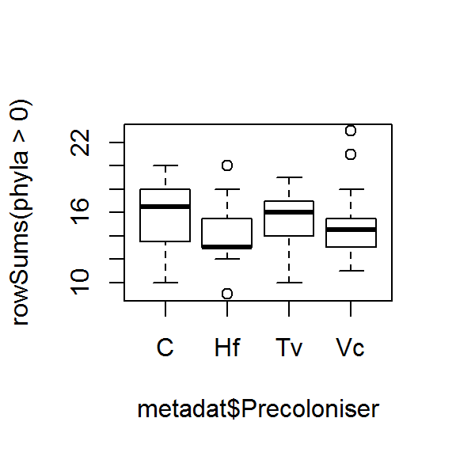

```r
#Sum counts within phyla
phyla<-do.call(data.frame, aggregate(taxbact[,2:92], list(Phylum=taxbact$Phylum), FUN=sum))
phyla<-as.data.frame(t(phyla[,-1]))
phyla<-phyla[order(Sample.ID),] ##NB for this to work, Sample.ID must be stored from sorting the main OTU table

#Raw data graphing - number of phyla in each sample type
plot(rowSums(phyla > 0)~metadat$Precoloniser)
```

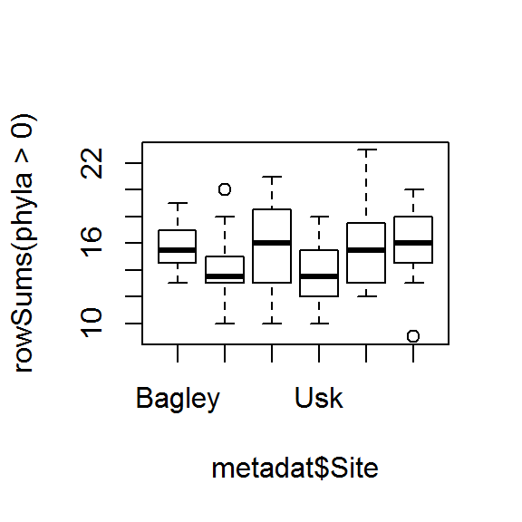

```r
plot(rowSums(phyla > 0)~metadat$Site)
```

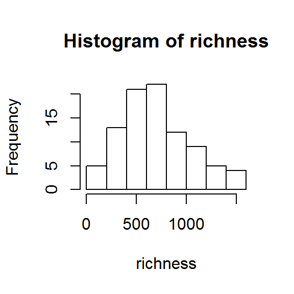

```r
###Richness plotting
richness<-rowSums(msbact>0) #Counts the number of occurrances for each OTU (because TRUE=1, FALSE=0)
hist(richness)
```

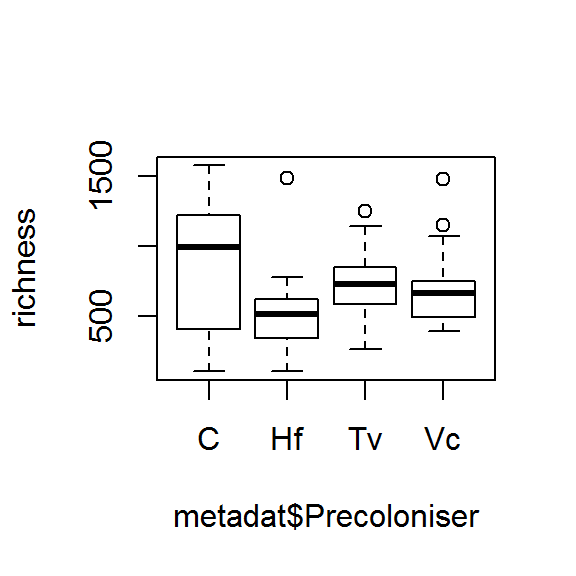

```r
#Plot richness against precoloniser
plot(richness~metadat$Precoloniser)
```

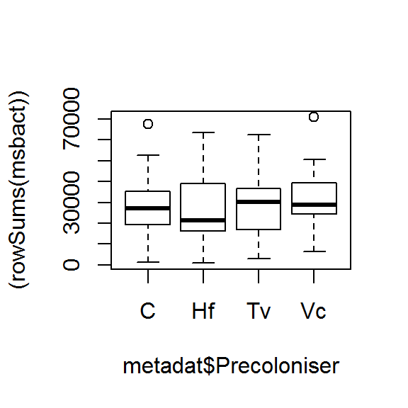

```r
#Compare for sequencing depth against precoloniser
plot((rowSums(msbact))~metadat$Precoloniser)
```

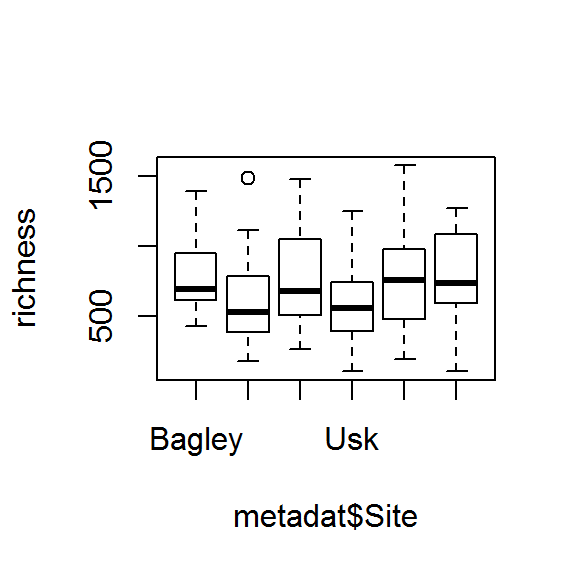

```r
#Do the same for site
plot(richness~metadat$Site)
```

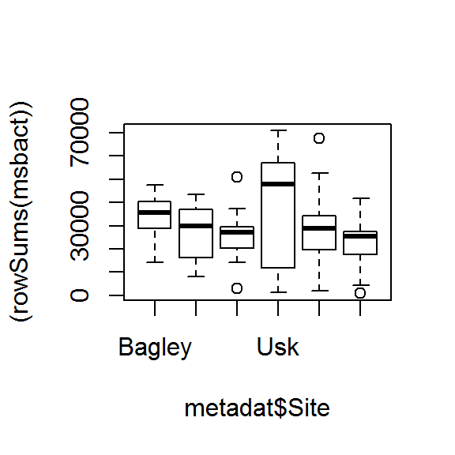

```r
#Plot sequencing depth against site
plot((rowSums(msbact))~metadat$Site)
```

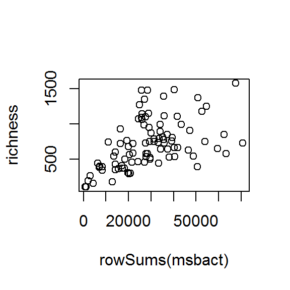

```r
#Plot richness against sequencing depth
plot(richness~(rowSums(msbact)))
```

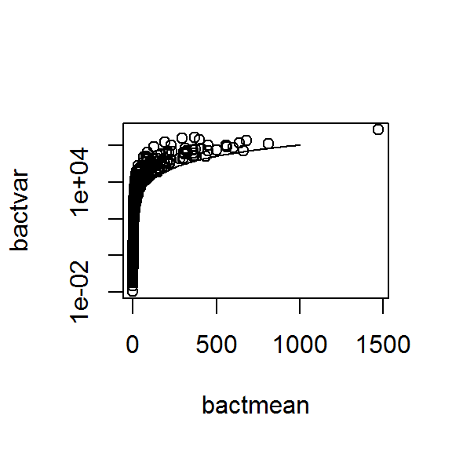

```r
##Plot the mean-variance relationship to look for overdipersion
#Calculate the mean and variance for each column
bactmean<-apply (msbact, 2, mean)
bactvar<- apply (msbact, 2, var)
#Plot them against each other
#The original plot was squashed because of a few large values, so use log y-axis; can chose only to view lower end by adding ', xlim=c(0,500), ylim=c(0, 1.5e+06)'
plot (bactvar~bactmean, log='y')
#Add in a curved line of slope y=x^2
curve(x^2, 0, 1000, add=TRUE)
```

```r
##Plot explanatory variables against each other (Fig 1 panels a-e)
pdf("predictor_relationships.pdf", height=12, width=8)
{
par(mfrow=c(3,2))
plot(metadat$Wood.pH~metadat$Precoloniser, notch=TRUE, xlab="Precoloniser", ylab="Wood pH")
mtext("(a)", side=3, adj=-0.2)
plot(metadat$Soil.pH~metadat$Precoloniser, notch=TRUE, xlab="Precoloniser", ylab="Soil pH")
mtext("(b)", side=3, adj=-0.2)

plot(metadat$Wood.pH~metadat$Site, notch=TRUE, xlab="Site", ylab="Wood pH", names=c("Bagley","Garth","Tintern","Usk","W'stone","W'ham"))
mtext("(c)", side=3, adj=-0.2)
plot(metadat$Soil.pH~metadat$Site, notch=TRUE, xlab="Site", ylab="Soil pH", names=c("Bagley","Garth","Tintern","Usk","W'stone","W'ham"))
mtext("(d)", side=3, adj=-0.2)

plot(metadat$Wood.pH~metadat$Soil.pH, xlab="Soil pH", ylab="Wood pH")
mtext("(e)", side=3, adj=-0.2)
mtext("(e)", side=3, adj=-0.2)}
dev.off()
```

### Rarefying exploration

```r
#Subsample down to lowest read number - 866 (Wy21)
rar1<-rrarefy(msbact, 866)

#Use two cores to do 100 repetitions of this subsampling and save them as elements in a list
#Aim to reduce subsampling bias by bootstrapping
cl <- makeCluster(2)
registerDoParallel(cl)
getDoParWorkers()
```

```
## [1] 2
```

```r
#At 866 samples
rarifylist<-foreach(i=1:100, .packages = c("vegan")) %dopar% {
  rrarefy(msbact, 866)
}
#At 1261 samples (second-lowest read number)
lost1<-msbact[-which(rowSums(msbact)==866),]
rarifylist2<-foreach(i=1:100, .packages = c("vegan")) %dopar% {
  rrarefy(lost1, 1261)
}

stopCluster(cl)

#Average multiple rarifactions and output as a matrix
meanrar<-apply(simplify2array(rarifylist), 1:2, mean)
meanrar2<-apply(simplify2array(rarifylist2), 1:2, mean)

#Count the number of columns with zero sums and remove them
sum(colSums(meanrar)==0)
```

```
## [1] 25
```

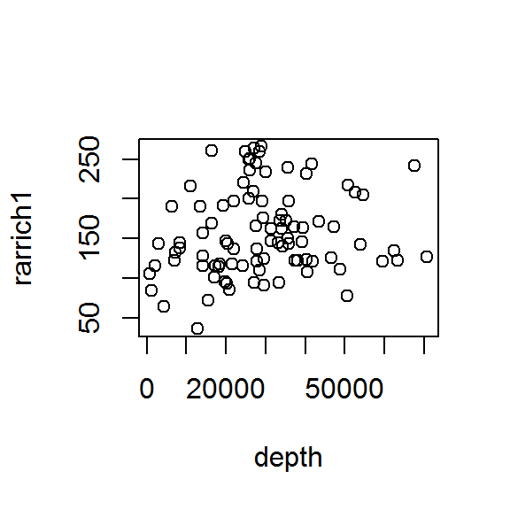

```r
meanrar<-meanrar[,(!colSums(meanrar)==0)]

#Richness for the single-rarefied data
rarrich1<-rowSums(rar1>0)
plot(rarrich1~depth)
```

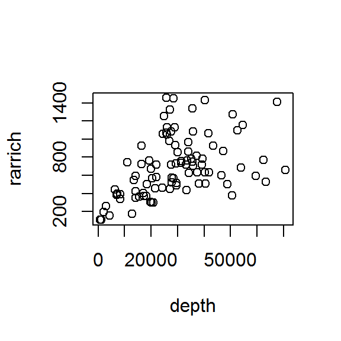

```r
#Now do richness for averaged rarefied data
rarrich<-rowSums(meanrar>0)
#Plot it against seqeuncing depth
plot(rarrich~depth)
```

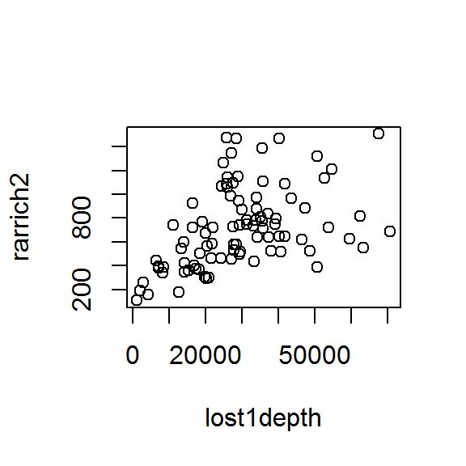

```r
#...and averaged data rarefied to a deeper level
rarrich2<-rowSums(meanrar2>0)
lost1depth<-(rowSums(msbact[-which(rowSums(msbact)==866),]))
plot(rarrich2~lost1depth)
```

Multiple rarefactions combined preserve the data structure including richness issues. A single rarefaction will only select some of the rare taxa in highly-sequenced samples. Repeated rarefactions differ in which of those rare taxa are selected. Averaging rarefactions will encompass all those taxa, preserving the richness of the original sample – and the richness-depth relationship.

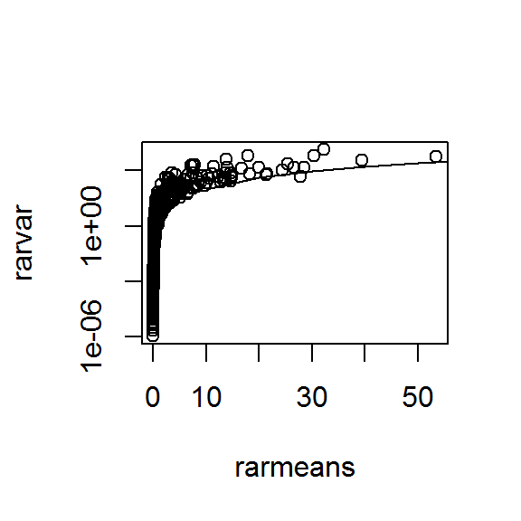

```r
#Plot the mean-variance relationship to look for overdispersion
rarmeans<-apply (meanrar2, 2, mean)
rarvar<- apply (meanrar2, 2, var)
plot (rarvar~rarmeans, log='y')
curve(x^2, 0, 1000, add=TRUE)
```

```r
#Rarefied data is still overdispersed (as expected - McMurdie & Holmes 2014)

#Fourth root transformation
froot=(rar1)^(1/4)

#Test for equal dispersion between treatments (important for PERMANOVA). Fourth root transformed data used to squash abundance differences.
dist <- vegdist((froot), method="bray")
betadisper(dist, metadat$Precoloniser)
```

```
##
##  Homogeneity of multivariate dispersions
##
## Call: betadisper(d = dist, group = metadat$Precoloniser)
##
## No. of Positive Eigenvalues: 89
## No. of Negative Eigenvalues: 1
##
## Average distance to median:
##      C     Hf     Tv     Vc
## 0.4963 0.3761 0.4920 0.4580
##
## Eigenvalues for PCoA axes:
##  PCoA1  PCoA2  PCoA3  PCoA4  PCoA5  PCoA6  PCoA7  PCoA8
## 5.4067 1.6993 1.1593 0.9030 0.8274 0.6617 0.5736 0.5003
```

```r
distmod <- anova(betadisper (dist, metadat$Precoloniser))
distmod
```

```
## Analysis of Variance Table
##
## Response: Distances
##           Df Sum Sq  Mean Sq F value    Pr(>F)
## Groups     3 0.1958 0.065266  6.8809 0.0003265 ***
## Residuals 87 0.8252 0.009485
## ---
## Signif. codes:  0 '***' 0.001 '**' 0.01 '*' 0.05 '.' 0.1 ' ' 1
```

```r
TukeyHSD(betadisper (dist, metadat$Precoloniser))
```

```
##   Tukey multiple comparisons of means
##     95% family-wise confidence level
##
## Fit: aov(formula = distances ~ group, data = df)
##
## $group
##               diff          lwr         upr     p adj
## Hf-C  -0.120192616 -0.197429810 -0.04295542 0.0005759
## Tv-C  -0.004352084 -0.078791020  0.07008685 0.9987107
## Vc-C  -0.038340998 -0.111983773  0.03530178 0.5253520
## Tv-Hf  0.115840532  0.037843859  0.19383721 0.0011036
## Vc-Hf  0.081851618  0.004614424  0.15908881 0.0334641
## Vc-Tv -0.033988914 -0.108427850  0.04045002 0.6310003
```

```r
#Single-rarefied data show unequal dispersion between Hf and other treatments; fourth-root transformation couldn’t remove it
#The averaged-rarefied data show the same unequal dispersion; fourth-root transformation barely removes it

#Test for equal dispersion on unrarified data.
dist2 <- vegdist((msbact), method="bray")
betadisper(dist2, metadat$Precoloniser)
```

```
##
##  Homogeneity of multivariate dispersions
##
## Call: betadisper(d = dist2, group = metadat$Precoloniser)
##
## No. of Positive Eigenvalues: 80
## No. of Negative Eigenvalues: 10
##
## Average distance to median:
##      C     Hf     Tv     Vc
## 0.5201 0.4362 0.5310 0.5055
##
## Eigenvalues for PCoA axes:
##  PCoA1  PCoA2  PCoA3  PCoA4  PCoA5  PCoA6  PCoA7  PCoA8
## 5.8944 2.8966 1.9145 1.5302 1.2722 1.0964 0.9199 0.8533
```

```r
disp.model2 <- anova(betadisper (dist2, metadat$Precoloniser))
disp.model2
```

```
## Analysis of Variance Table
##
## Response: Distances
##           Df  Sum Sq  Mean Sq F value Pr(>F)
## Groups     3 0.11369 0.037898  2.1433 0.1006
## Residuals 87 1.53834 0.017682
```

```r
TukeyHSD(betadisper (dist2, metadat$Precoloniser))
```

```
##   Tukey multiple comparisons of means
##     95% family-wise confidence level
##
## Fit: aov(formula = distances ~ group, data = df)
##
## $group
##              diff         lwr        upr     p adj
## Hf-C  -0.08380824 -0.18926455 0.02164807 0.1672311
## Tv-C   0.01091075 -0.09072494 0.11254644 0.9921878
## Vc-C  -0.01455496 -0.11510361 0.08599368 0.9813162
## Tv-Hf  0.09471900 -0.01177427 0.20121227 0.0991672
## Vc-Hf  0.06925328 -0.03620303 0.17470959 0.3195633
## Vc-Tv -0.02546572 -0.12710141 0.07616998 0.9130568
```

```r
#Raw data does not show unequal dispersion between groups
```

### Explore the fungal data

```r
#Find which fungal OTU is dominant in each sample
#Write a function to find the highest value in a row (sample) and return the corresponding column name (OTU ID)
find.top.name<-function(x){
  (colnames(fungi)[(which.max(x))])
}
#Apply it to the fungal dataset
top.names<-apply(fungi, 1, find.top.name)
#Find what percentage of reads the top OTU accounts for in each sample
top.vals<-apply(funprops, 1, max)
#Make them into a data frame and add a column with the sample ID
tops<-cbind.data.frame(top.names, top.vals)
tops$Sample.ID<-metadat$X.SampleID

#Pull out the corresponding species name for the top OTU in each sample
find.identity<-function(x){
  t<-match(x, blast$Name)
  return(blast$Species[t])
}
tops$Species<-lapply(tops$top.names, find.identity)
tops$Species<-unlist(tops$Species)
tops$Species<-as.factor(tops$Species)

#Do the same for the genus name for the top OTU in each sample
find.genus<-function(x){
  t<-match(x, blast$Name)
  return(blast$X.15[t])
}
tops$Genus<-lapply(tops$top.names, find.genus)
tops$Genus<-unlist(tops$Genus)
tops$Genus<-as.factor(tops$Genus)

#Do the same for phylum name for the top OTU in each sample
find.phylum<-function(x){
  t<-match(x, blast$Name)
  return(blast$X.2[t])
}
tops$phylum<-lapply(tops$top.names, find.phylum)
tops$phylum<-unlist(tops$phylum)
tops$phylum<-as.factor(tops$phylum)

#List whether the top OTU in each sample is classifed as decomposer or a co-coloniser (see Hiscox *et al.*, 2016 for details)
find.decomp<-function(x){
  t<-match(x, blast$Name)
  return(blast$Co.col.or.decomp[t])
}
tops$decomp<-lapply(tops$top.names, find.decomp)
tops$decomp<-unlist(tops$decomp)
tops$decomp<-as.factor(tops$decomp)


#Where the top OTU is a co-coloniser, see what % reads it accounts for compared to when it is a decomposer
summary(subset(tops$top.vals, tops$decomp=="C"))
```

```
##    Min. 1st Qu.  Median    Mean 3rd Qu.    Max.
##  0.1804  0.2985  0.3919  0.4667  0.6802  0.8790
```

```r
summary(subset(tops$top.vals, tops$decomp=="D"))
```

```
##    Min. 1st Qu.  Median    Mean 3rd Qu.    Max.
##  0.2067  0.5281  0.8131  0.7429  0.9808  0.9996
```

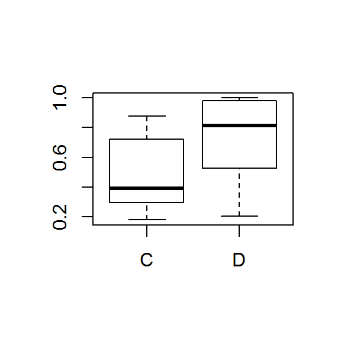

```r
boxplot(tops$top.vals~tops$decomp)
```

```r
#List whether the top OTU in each sample comes from a genus of known cordformers
#See what genera are represented
levels(tops$Genus)
```

```
##  [1] "Ceriporia"      "Chaetosphaeria" "Chalara"        "Coprinopsis"
##  [5] "Crepidotus"     "Dactylella"     "Hypholoma"      "Lasiosphaeris"
##  [9] "Megacollybia"   "Mutinus"        "Mycena"         "n"
## [13] "Phallus"        "Phialocephala"  "Psathyrella"    "Resinicium"
## [17] "Scopuloides"    "Sistotrema"     "Tubaria"
```

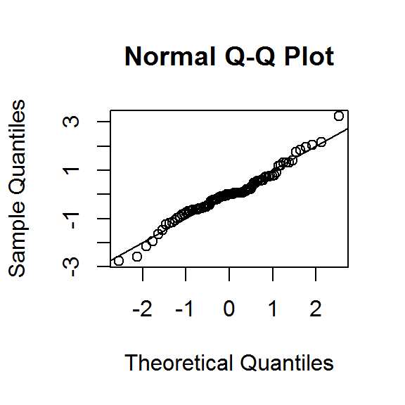

```r
tops$cords<-ifelse (tops$Genus=="Hypholoma"|tops$Genus=="Megacollybia"|tops$Genus=="Mutinus"|tops$Genus=="Phallus"|tops$Genus=="Resinicium", "CF", "Non-CF")
tops$cords<-as.factor(tops$cords)
tops$cords<-relevel(tops$cords, ref="Non-CF")

#Calculate the proportion of ascomycetess vs basidiomycetess in each disk
ascoprop<-rowSums(subset(funprops, select=(as.character(subset(blast$Name, blast$X.2=="Ascomycota")))))
basidprop<-rowSums(subset(funprops, select=(as.character(subset(blast$Name, blast$X.2=="Basidiomycota")))))
#Convert it to a value between 0-255, for later use in plotting
ascotransp<-ascoprop*255
basidtransp<-basidprop*255

#Find out how much variation in wood pH is explained by fungus present
woodan<-lm(metadat$Wood.pH~tops$Genus)
wasresid<-(woodan$residuals-mean(woodan$residuals))/sd(woodan$residuals)
qqnorm(wasresid)
abline(0, 1)
```

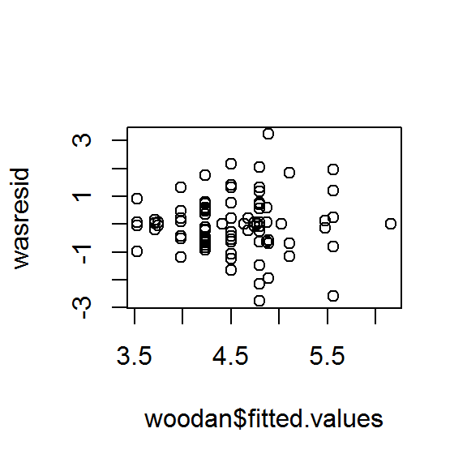

```r
plot(wasresid~woodan$fitted.values)
```

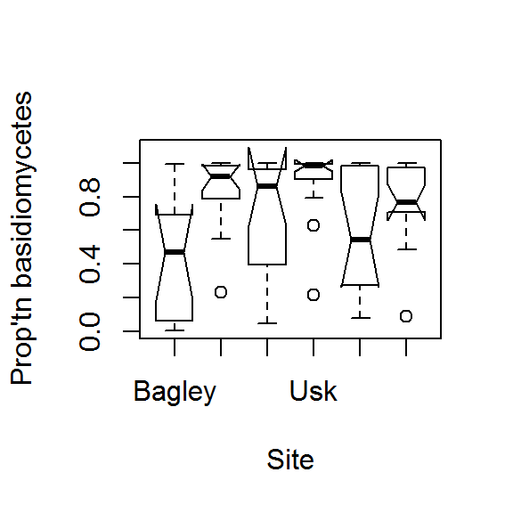

```r
#Plot the proportion of basidiomycetes on each site (Fig 1 panel f)
plot(basidprop~metadat$Site, notch=TRUE, xlab="Site", ylab="Prop'tn basidiomycetes", names=c("Bagley","Garth","Tintern","Usk","W'stone","Wytham"))
```

## Ordination of the bacterial data

```r
#Bray-Curtis NMDS on raw data
BCnmds2 <- metaMDS(msbact, trymax = 500, k=2, pc="TRUE", distance = "bray", autotransform = FALSE)
```

```r
BCnmds2
```

```
##
## Call:
## metaMDS(comm = msbact, distance = "bray", k = 2, trymax = 500,      autotransform = FALSE, pc = "TRUE")
##
## global Multidimensional Scaling using monoMDS
##
## Data:     msbact
## Distance: bray
##
## Dimensions: 2
## Stress:     0.1471865
## Stress type 1, weak ties
## Two convergent solutions found after 47 tries
## Scaling: centring, PC rotation, halfchange scaling
## Species: expanded scores based on 'msbact'
```

```r
#Colour by sequencing depth (Fig S2)
pdf("NMDS_depth.pdf", width =8, height=6)
plot(BCnmds2$points, pch=20, col=rgb(red=255,blue=0,green=0,alpha=grad,maxColorValue=255))
dev.off()
```

Panelled graph showing the ordination plot coloured by explanatory variables (precol, site, wood pH, soil pH, persistance, genus, asco v basid, cord-formers) (Fig 2)

```r
pdf("eightway_NMDS.pdf")
{
par(mfrow=c(4,2), mar=c(5,5,1,1))
#Colour by precoloniser
plot(BCnmds2$points, type="n", xlim=c(-2.5, 1.5))
legend("topleft",  c("Control","Vc", "Tv", "Hf"), pch=c(20,20,20,20), bty="n", cex=0.8,
       col=c((rgb(red=0,blue=0,green=0,maxColorValue=255)),(rgb(red=0,blue=255,green=0,maxColorValue=255)),(rgb(red=0,blue=0,green=255,maxColorValue=255)),(rgb(red=255,blue=0,green=0,maxColorValue=255))))
mtext("(a)", side=3, adj=-0.2)
points((subset(BCnmds2$points, metadat$Precoloniser=="C")), pch=20, col=rgb(red=0,blue=0,green=0,maxColorValue=255))
points((subset(BCnmds2$points, metadat$Precoloniser=="Vc")), pch=20, col=rgb(red=0,blue=255,green=0,maxColorValue=255))
points((subset(BCnmds2$points, metadat$Precoloniser=="Tv")), pch=20, col=rgb(red=0,blue=0,green=255,maxColorValue=255))
points((subset(BCnmds2$points, metadat$Precoloniser=="Hf")), pch=20, col=rgb(red=255,blue=0,green=0,maxColorValue=255))
#Colour by site
plot(BCnmds2$points, type="n", xlim=c(-2.5, 1.5))
legend("topleft",  c("Bagley","Garth","Tintern","Usk","Wh'stone","Wytham"), pch=c(20,20,20,20), bty="n",  cex=0.8,
       col=c((rgb(red=255,blue=0,green=0,maxColorValue=255)),(rgb(red=0,blue=255,green=0,maxColorValue=255)),(rgb(red=0,blue=0,green=255,maxColorValue=255)),
             (rgb(red=255,blue=255,green=0,maxColorValue=255)),(rgb(red=0,blue=255,green=255,maxColorValue=255)),(rgb(red=255,blue=0,green=200,maxColorValue=255))))
mtext("(b)", side=3, adj=-0.2)
points((subset(BCnmds2$points, metadat$Site=="Bagley")), pch=20, col=rgb(red=255,blue=0,green=0,maxColorValue=255))
points((subset(BCnmds2$points, metadat$Site=="Garth")), pch=20, col=rgb(red=0,blue=255,green=0,maxColorValue=255))
points((subset(BCnmds2$points, metadat$Site=="Tintern")), pch=20, col=rgb(red=0,blue=0,green=255,maxColorValue=255))
points((subset(BCnmds2$points, metadat$Site=="Usk")), pch=20, col=rgb(red=255,blue=255,green=0,maxColorValue=255))
points(subset(BCnmds2$points, metadat$Site=="Whitestone"), pch=20, col=rgb(red=0,blue=255,green=255,maxColorValue=255))
points((subset(BCnmds2$points, metadat$Site=="Wytham")), pch=20, col=rgb(red=255,blue=0,green=200,maxColorValue=255))
#By wood pH
plot(BCnmds2$points, pch=20, xlim=c(-2.5, 1.5), col=rgb(red=200,blue=100,green=0,alpha=woodgrad,maxColorValue=255))
mtext("(c)", side=3, adj=-0.2)
#By soil pH
plot(BCnmds2$points, pch=20, xlim=c(-2.5, 1.5), col=rgb(red=200,blue=0,green=100,alpha=soilgrad,maxColorValue=255))
mtext("(d)", side=3, adj=-0.2)
#By precoloniser persistance, with transparency dictated by proportion of disk occupied at the time of collection
cpersist<-(subset(metadat$Persistance, metadat$Precoloniser=="C"))*2.55
vcpersist<-(subset(metadat$Persistance, metadat$Precoloniser=="Vc"))*2.55
tvpersist<-(subset(metadat$Persistance, metadat$Precoloniser=="Tv"))*2.55
hfpersist<-(subset(metadat$Persistance, metadat$Precoloniser=="Hf"))*2.55
plot(BCnmds2$points, pch=20, type="n", xlim=c(-2.5, 1.5))
legend("topleft",  c("Control","Vc", "Tv", "Hf"), pch=c(20,20,20,20), bty="n", cex=0.8,
       col=c((rgb(red=0,blue=0,green=0,maxColorValue=255)),(rgb(red=0,blue=255,green=0,maxColorValue=255)),(rgb(red=0,blue=0,green=255,maxColorValue=255)),(rgb(red=255,blue=0,green=0,maxColorValue=255))))
mtext("(e)", side=3, adj=-0.2)
points((subset(BCnmds2$points, metadat$Precoloniser=="C")), pch=20, col=rgb(red=0,blue=0,green=0,alpha=cpersist,maxColorValue=255))
points((subset(BCnmds2$points, metadat$Precoloniser=="Vc")), pch=20, col=rgb(red=0,blue=255,green=0,alpha=vcpersist,maxColorValue=255))
points((subset(BCnmds2$points, metadat$Precoloniser=="Tv")), pch=20, col=rgb(red=0,blue=0,green=255,alpha=tvpersist,maxColorValue=255))
points((subset(BCnmds2$points, metadat$Precoloniser=="Hf")), pch=20, col=rgb(red=255,blue=0,green=0,alpha=hfpersist,maxColorValue=255))
#Colour by the genus of the dominant fungal OTU (only genera with >= 3 occurrances)
plot(BCnmds2$points, type="n", xlim=c(-2.5, 1.5))
legend("topleft",  c("Chalara","Hypholoma", "Lasiosphaeris", "Megacollybia","Mutinus","Phallus","Psathyrella","Scopuloides","Tubaria"),
  pch=c(20,20,20,20,20,20,20,20), bty="n",cex=0.7,
  col=c(rgb(red=0,blue=0,green=0,maxColorValue=255),#black
    rgb(red=255,blue=0,green=0,maxColorValue=255),#red
    rgb(red=120,blue=60,green=60,maxColorValue=255),#brown
    rgb(red=225,blue=50,green=150,maxColorValue=255),#orange
    rgb(red=0,blue=0,green=255,maxColorValue=255),#green
    rgb(red=255,blue=0,green=200,maxColorValue=255),#yellow
    rgb(red=0,blue=255,green=255,maxColorValue=255),#cyan
    rgb(red=0,blue=255,green=0,maxColorValue=255),#blue
    rgb(red=255,blue=255,green=0,maxColorValue=255))#magenta
)
mtext("(f)", side=3, adj=-0.2)
points((subset(BCnmds2$points, tops$Genus=="Chalara")), pch=20, col=rgb(red=0,blue=0,green=0,maxColorValue=255))#black
points((subset(BCnmds2$points, tops$Genus=="Hypholoma")), pch=20, col=rgb(red=255,blue=0,green=0,maxColorValue=255))#red
points((subset(BCnmds2$points, tops$Genus=="Lasiosphaeris")), pch=20, col=rgb(red=120,blue=60,green=60,maxColorValue=255))#brown
points((subset(BCnmds2$points, tops$Genus=="Megacollybia")), pch=20, col=rgb(red=225,blue=50,green=150,maxColorValue=255))#orange
points((subset(BCnmds2$points, tops$Genus=="Mutinus")), pch=20, col=rgb(red=0,blue=0,green=255,maxColorValue=255))#green
points((subset(BCnmds2$points, tops$Genus=="Phallus")), pch=20, col=rgb(red=255,blue=0,green=200,maxColorValue=255))#yellow
points((subset(BCnmds2$points, tops$Genus=="Psathyrella")), pch=20, col=rgb(red=0,blue=255,green=255,maxColorValue=255))#cyan
points((subset(BCnmds2$points, tops$Genus=="Scopuloides")), pch=20, col=rgb(red=0,blue=255,green=0,maxColorValue=255))#blue
points((subset(BCnmds2$points, tops$Genus=="Tubaria")), pch=20, col=rgb(red=255,blue=255,green=0,maxColorValue=255))#magenta
#Colour by proportion of ascos vs basids
plot(BCnmds2$points, type="n", xlim=c(-2.5, 1.5))
legend("topleft",  c("Ascomycetes","Basidiomycetes"), pch=c(20,20), bty="n",cex=0.8,
       col=c((rgb(red=255,blue=0,green=0,maxColorValue=255)),(rgb(red=0,blue=255,green=0,maxColorValue=255))))
mtext("(g)", side=3, adj=-0.2)
points(BCnmds2$points, pch=20, col=rgb(red=ascotransp,blue=basidtransp,green=0,maxColorValue=255))
#Colour by whether the top fungal OTU is a known cord-former, with transparency dictated by % of the disk it occupies
plot(BCnmds2$points, type="n", xlim=c(-2.5, 1.5))
legend("topleft",  c("Cord-former","Other"), pch=c(20,20), bty="n",cex=0.8,
       col=c((rgb(red=255,blue=0,green=0,maxColorValue=255)),(rgb(red=0,blue=0,green=0,maxColorValue=255))))
mtext("(h)", side=3, adj=-0.2)
cordtransp<-split(tops$top.vals*255, tops$cords)
points((subset(BCnmds2$points, tops$cords=="CF")), pch=20, col=rgb(red=255,blue=0,green=0,alpha=cordtransp$CF,maxColorValue=255))
points((subset(BCnmds2$points, tops$cords=="Non-CF")), pch=20, col=rgb(red=0,blue=0,green=0,alpha=cordtransp$`Non-CF`,maxColorValue=255))
}
dev.off()
```

Plot the ordination panelled by site, coloured by precoloniser (Fig S3)

```r
pdf("panelled_by_site.pdf")
par(mfrow=c(3,2))
for (i in levels(metadat$Site))
{
  plot(BCnmds2$points, type="n", main={i})
  points((subset(BCnmds2$points, metadat$Precoloniser=="C" & metadat$Site=={i})), pch=20, cex=1.8, col=rgb(red=0,blue=0,green=0,maxColorValue=255))
  points((subset(BCnmds2$points, metadat$Precoloniser=="Vc" & metadat$Site=={i})), pch=20, cex=1.8, col=rgb(red=0,blue=255,green=0,maxColorValue=255))
  points((subset(BCnmds2$points, metadat$Precoloniser=="Tv" & metadat$Site=={i})), pch=20, cex=1.8, col=rgb(red=0,blue=0,green=255,maxColorValue=255))
  points((subset(BCnmds2$points, metadat$Precoloniser=="Hf" & metadat$Site=={i})), pch=20, cex=1.8, col=rgb(red=255,blue=0,green=0,maxColorValue=255))
}
dev.off()
```

PCA with Hellinger transformation, for comparison with NMDS

```r
hpca<-prcomp(decostand(msbact, "hellinger"))
summary(hpca)
```

```
## Importance of components:
##                           PC1     PC2     PC3     PC4     PC5     PC6
## Standard deviation     0.3674 0.22957 0.18636 0.16554 0.15597 0.13867
## Proportion of Variance 0.2378 0.09284 0.06118 0.04827 0.04286 0.03387
## Cumulative Proportion  0.2378 0.33068 0.39187 0.44014 0.48300 0.51687
##                            PC7     PC8     PC9    PC10    PC11    PC12
## Standard deviation     0.13292 0.11658 0.10946 0.10552 0.09893 0.09425
## Proportion of Variance 0.03112 0.02394 0.02111 0.01961 0.01724 0.01565
## Cumulative Proportion  0.54799 0.57194 0.59304 0.61266 0.62990 0.64555
##                           PC13    PC14    PC15    PC16    PC17    PC18
## Standard deviation     0.09287 0.08730 0.08686 0.08472 0.08279 0.08039
## Proportion of Variance 0.01519 0.01343 0.01329 0.01264 0.01207 0.01139
## Cumulative Proportion  0.66074 0.67417 0.68746 0.70010 0.71217 0.72356
##                           PC19    PC20    PC21    PC22    PC23    PC24
## Standard deviation     0.07894 0.07777 0.07671 0.07424 0.07248 0.07159
## Proportion of Variance 0.01098 0.01065 0.01037 0.00971 0.00925 0.00903
## Cumulative Proportion  0.73453 0.74519 0.75555 0.76526 0.77452 0.78355
##                           PC25    PC26    PC27    PC28    PC29    PC30
## Standard deviation     0.06888 0.06748 0.06670 0.06556 0.06456 0.06364
## Proportion of Variance 0.00836 0.00802 0.00784 0.00757 0.00734 0.00713
## Cumulative Proportion  0.79190 0.79993 0.80776 0.81534 0.82268 0.82981
##                           PC31    PC32    PC33    PC34    PC35    PC36
## Standard deviation     0.06157 0.06052 0.05943 0.05711 0.05676 0.05464
## Proportion of Variance 0.00668 0.00645 0.00622 0.00575 0.00567 0.00526
## Cumulative Proportion  0.83649 0.84294 0.84916 0.85491 0.86058 0.86584
##                           PC37    PC38    PC39    PC40    PC41    PC42
## Standard deviation     0.05397 0.05304 0.05215 0.05164 0.05064 0.04953
## Proportion of Variance 0.00513 0.00496 0.00479 0.00470 0.00452 0.00432
## Cumulative Proportion  0.87097 0.87593 0.88072 0.88542 0.88994 0.89426
##                           PC43    PC44    PC45    PC46    PC47    PC48
## Standard deviation     0.04904 0.04770 0.04731 0.04587 0.04530 0.04465
## Proportion of Variance 0.00424 0.00401 0.00394 0.00371 0.00361 0.00351
## Cumulative Proportion  0.89849 0.90250 0.90644 0.91015 0.91376 0.91728
##                           PC49    PC50    PC51    PC52    PC53    PC54
## Standard deviation     0.04428 0.04344 0.04327 0.04258 0.04190 0.04111
## Proportion of Variance 0.00345 0.00332 0.00330 0.00319 0.00309 0.00298
## Cumulative Proportion  0.92073 0.92405 0.92735 0.93055 0.93364 0.93662
##                           PC55    PC56    PC57    PC58    PC59    PC60
## Standard deviation     0.04066 0.04012 0.03904 0.03854 0.03826 0.03753
## Proportion of Variance 0.00291 0.00284 0.00268 0.00262 0.00258 0.00248
```

[output cut: 10 more lines]

```
## Standard deviation     0.03093 0.03074 0.03014 0.02991 0.02884 0.02826
## Proportion of Variance 0.00168 0.00167 0.00160 0.00158 0.00147 0.00141
## Cumulative Proportion  0.97924 0.98091 0.98251 0.98408 0.98555 0.98696
##                           PC79    PC80    PC81    PC82    PC83    PC84
## Standard deviation     0.02764 0.02726 0.02686 0.02673 0.02629 0.02594
## Proportion of Variance 0.00135 0.00131 0.00127 0.00126 0.00122 0.00119
## Cumulative Proportion  0.98830 0.98961 0.99088 0.99214 0.99336 0.99454
##                           PC85    PC86    PC87   PC88    PC89    PC90
## Standard deviation     0.02452 0.02395 0.02350 0.0226 0.02121 0.02024
## Proportion of Variance 0.00106 0.00101 0.00097 0.0009 0.00079 0.00072
## Cumulative Proportion  0.99560 0.99661 0.99759 0.9985 0.99928 1.00000
##                             PC91
## Standard deviation     3.938e-16
## Proportion of Variance 0.000e+00
## Cumulative Proportion  1.000e+00
```

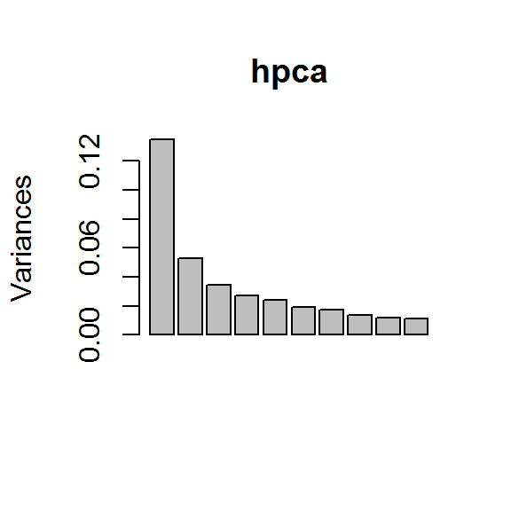

```r
plot(hpca)
```

```r
hpca$sdev^2
```

```
##  [1] 1.350122e-01 5.270301e-02 3.473180e-02 2.740375e-02 2.432819e-02
##  [6] 1.922876e-02 1.766676e-02 1.359085e-02 1.198200e-02 1.113394e-02
## [11] 9.786759e-03 8.882633e-03 8.624341e-03 7.622116e-03 7.544253e-03
## [16] 7.176662e-03 6.853937e-03 6.462895e-03 6.230816e-03 6.047603e-03
## [21] 5.885171e-03 5.511482e-03 5.252694e-03 5.125640e-03 4.744326e-03
## [26] 4.553775e-03 4.448929e-03 4.298244e-03 4.167813e-03 4.050095e-03
## [31] 3.790790e-03 3.662304e-03 3.531924e-03 3.261291e-03 3.221191e-03
## [36] 2.985179e-03 2.912893e-03 2.812929e-03 2.719335e-03 2.666866e-03
## [41] 2.564636e-03 2.452744e-03 2.404469e-03 2.274821e-03 2.238620e-03
## [46] 2.104163e-03 2.051773e-03 1.993920e-03 1.960286e-03 1.886825e-03
## [51] 1.872656e-03 1.812651e-03 1.755591e-03 1.689909e-03 1.653088e-03
## [56] 1.609651e-03 1.524114e-03 1.485529e-03 1.463977e-03 1.408241e-03
## [61] 1.371258e-03 1.350623e-03 1.313084e-03 1.288497e-03 1.189229e-03
## [66] 1.157327e-03 1.135333e-03 1.103376e-03 1.082248e-03 1.061559e-03
## [71] 1.029668e-03 1.014386e-03 9.564599e-04 9.452016e-04 9.087174e-04
## [76] 8.946699e-04 8.318643e-04 7.985539e-04 7.642403e-04 7.428412e-04
## [81] 7.217107e-04 7.145145e-04 6.909273e-04 6.728034e-04 6.009924e-04
## [86] 5.736177e-04 5.524086e-04 5.108186e-04 4.496575e-04 4.098468e-04
## [91] 1.550819e-31
```

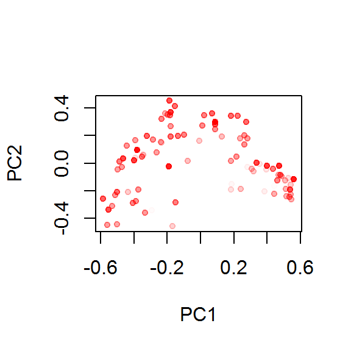

```r
#Plot coloured by sequencing depth
plot(hpca$x, pch=20, col=rgb(red=255,blue=0,green=0,alpha=grad,maxColorValue=255))
```

Panelled graph showing the ordination plot coloured by explanatory variables (precol, site, wood pH, soil pH, persistance, cord-formers) (Fig. S1)

```r
pdf("hellinger_plots.pdf")
{
par(mfrow=c(3,2))
#By precoloniser
plot(hpca$x, type="n")
legend("topleft",  c("Control","Vc", "Tv", "Hf"), pch=c(20,20,20,20), bty="n",
       col=c((rgb(red=0,blue=0,green=0,maxColorValue=255)),(rgb(red=0,blue=255,green=0,maxColorValue=255)),(rgb(red=0,blue=0,green=255,maxColorValue=255)),(rgb(red=255,blue=0,green=0,maxColorValue=255))))
mtext("(a)", side=3, adj=-0.2)
points((subset(hpca$x, metadat$Precoloniser=="C")), pch=20, col=rgb(red=0,blue=0,green=0,maxColorValue=255))
points((subset(hpca$x, metadat$Precoloniser=="Vc")), pch=20, col=rgb(red=0,blue=255,green=0,maxColorValue=255))
points((subset(hpca$x, metadat$Precoloniser=="Tv")), pch=20, col=rgb(red=0,blue=0,green=255,maxColorValue=255))
points((subset(hpca$x, metadat$Precoloniser=="Hf")), pch=20, col=rgb(red=255,blue=0,green=0,maxColorValue=255))
#By site
plot(hpca$x, type="n")
legend("topleft",  c("Bagley","Garth","Tintern","Usk","Wh'stone","Wytham"), pch=c(20,20,20,20), bty="n",
       col=c((rgb(red=255,blue=0,green=0,maxColorValue=255)),(rgb(red=0,blue=255,green=0,maxColorValue=255)),(rgb(red=0,blue=0,green=255,maxColorValue=255)),
             (rgb(red=255,blue=255,green=0,maxColorValue=255)),(rgb(red=0,blue=255,green=255,maxColorValue=255)),(rgb(red=255,blue=0,green=255,maxColorValue=255))))
mtext("(b)", side=3, adj=-0.2)
points((subset(hpca$x, metadat$Site=="Bagley")), pch=20, col=rgb(red=255,blue=0,green=0,maxColorValue=255))
points((subset(hpca$x, metadat$Site=="Garth")), pch=20, col=rgb(red=0,blue=255,green=0,maxColorValue=255))
points((subset(hpca$x, metadat$Site=="Tintern")), pch=20, col=rgb(red=0,blue=0,green=255,maxColorValue=255))
points((subset(hpca$x, metadat$Site=="Usk")), pch=20, col=rgb(red=255,blue=255,green=0,maxColorValue=255))
points((subset(hpca$x, metadat$Site=="Whitestone")), pch=20, col=rgb(red=0,blue=255,green=255,maxColorValue=255))
points((subset(hpca$x, metadat$Site=="Wytham")), pch=20, col=rgb(red=255,blue=0,green=255,maxColorValue=255))
#By wood pH
plot(hpca$x, pch=20, col=rgb(red=255,blue=100,green=0,alpha=woodgrad,maxColorValue=255))
mtext("(c)", side=3, adj=-0.2)
#By soil pH
plot(hpca$x, pch=20, col=rgb(red=255,blue=0,green=100,alpha=soilgrad,maxColorValue=255))
mtext("(d)", side=3, adj=-0.2)
#By precoloniser persistence
persist<-(metadat$Persistance)*1.25
plot(hpca$x, pch=20, col=rgb(red=0,blue=100,green=100,alpha=persist,maxColorValue=255))
mtext("(e)", side=3, adj=-0.2)
#By cord-formers
plot(hpca$x, type="n")
legend("topleft",  c("Cord-former","Other"), pch=c(20,20), bty="n",cex=0.8,
       col=c((rgb(red=255,blue=0,green=0,maxColorValue=255)),(rgb(red=0,blue=0,green=0,maxColorValue=255))))
mtext("(f)", side=3, adj=-0.2)
cordtransp<-split(tops$top.vals*255, tops$cords)
points((subset(hpca$x, tops$cords=="CF")), pch=20, col=rgb(red=255,blue=0,green=0,alpha=cordtransp$CF,maxColorValue=255))
points((subset(hpca$x, tops$cords=="Non-CF")), pch=20, col=rgb(red=0,blue=0,green=0,alpha=cordtransp$`Non-CF`,maxColorValue=255))
}
dev.off()
```

## PERMANOVA on the bacterial data

```r
#Test for equal dispersion on unrarified data.
dist2 <- vegdist((msbact), method="bray")
betadisper(dist2, metadat$Precoloniser)
disp.model2 <- anova(betadisper (dist2, metadat$Precoloniser))
disp.model2
TukeyHSD(betadisper (dist2, metadat$Precoloniser))

#PERMANOVA
pma<-adonis(msbact ~  metadat$Precoloniser*metadat$Site, permutations = 999, method = "bray", strata = NULL)
pma
boxplot(pma$coefficients~rownames(pma$coefficients))

#Pairwise comparisons between treatments
#Create a list containing subsets of the response variables (OTUS) in all pairwise combinations
pairslist<-list(
  BCVc=subset(msbact, (metadat$Precoloniser=="C" | metadat$Precoloniser=="Vc") & metadat$Site=="Bagley"),
  BCTv=subset(msbact, (metadat$Precoloniser=="C" | metadat$Precoloniser=="Tv") & metadat$Site=="Bagley"),
  BVcTv=subset(msbact, (metadat$Precoloniser=="Vc" | metadat$Precoloniser=="Tv") & metadat$Site=="Bagley"),

  GCVc=subset(msbact, (metadat$Precoloniser=="C" | metadat$Precoloniser=="Vc") & metadat$Site=="Garth"),
  GCTv=subset(msbact, (metadat$Precoloniser=="C" | metadat$Precoloniser=="Tv") & metadat$Site=="Garth"),
  GCHf=subset(msbact, (metadat$Precoloniser=="C" | metadat$Precoloniser=="Hf") & metadat$Site=="Garth"),
  GVcTv=subset(msbact, (metadat$Precoloniser=="Vc" | metadat$Precoloniser=="Tv") & metadat$Site=="Garth"),
  GVcHf=subset(msbact, (metadat$Precoloniser=="Vc" | metadat$Precoloniser=="Hf") & metadat$Site=="Garth"),
  GTvHf=subset(msbact, (metadat$Precoloniser=="Tv" | metadat$Precoloniser=="Hf") & metadat$Site=="Garth"),

  TCVc=subset(msbact, (metadat$Precoloniser=="C" | metadat$Precoloniser=="Vc") & metadat$Site=="Tintern"),
  TCTv=subset(msbact, (metadat$Precoloniser=="C" | metadat$Precoloniser=="Tv") & metadat$Site=="Tintern"),
  TCHf=subset(msbact, (metadat$Precoloniser=="C" | metadat$Precoloniser=="Hf") & metadat$Site=="Tintern"),
  TVcTv=subset(msbact, (metadat$Precoloniser=="Vc" | metadat$Precoloniser=="Tv") & metadat$Site=="Tintern"),
  TVcHf=subset(msbact, (metadat$Precoloniser=="Vc" | metadat$Precoloniser=="Hf") & metadat$Site=="Tintern"),
  TTvHf=subset(msbact, (metadat$Precoloniser=="Tv" | metadat$Precoloniser=="Hf") & metadat$Site=="Tintern"),

  UCVc=subset(msbact, (metadat$Precoloniser=="C" | metadat$Precoloniser=="Vc") & metadat$Site=="Usk"),
  UCTv=subset(msbact, (metadat$Precoloniser=="C" | metadat$Precoloniser=="Tv") & metadat$Site=="Usk"),
  UCHf=subset(msbact, (metadat$Precoloniser=="C" | metadat$Precoloniser=="Hf") & metadat$Site=="Usk"),
  UVcTv=subset(msbact, (metadat$Precoloniser=="Vc" | metadat$Precoloniser=="Tv") & metadat$Site=="Usk"),
  UVcHf=subset(msbact, (metadat$Precoloniser=="Vc" | metadat$Precoloniser=="Hf") & metadat$Site=="Usk"),
  UTvHf=subset(msbact, (metadat$Precoloniser=="Tv" | metadat$Precoloniser=="Hf") & metadat$Site=="Usk"),

  WsCVc=subset(msbact, (metadat$Precoloniser=="C" | metadat$Precoloniser=="Vc") & metadat$Site=="Whitestone"),
  WsCTv=subset(msbact, (metadat$Precoloniser=="C" | metadat$Precoloniser=="Tv") & metadat$Site=="Whitestone"),
  WsCHf=subset(msbact, (metadat$Precoloniser=="C" | metadat$Precoloniser=="Hf") & metadat$Site=="Whitestone"),
  WsVcTv=subset(msbact, (metadat$Precoloniser=="Vc" | metadat$Precoloniser=="Tv") & metadat$Site=="Whitestone"),
  WsVcHf=subset(msbact, (metadat$Precoloniser=="Vc" | metadat$Precoloniser=="Hf") & metadat$Site=="Whitestone"),
  WsTvHf=subset(msbact, (metadat$Precoloniser=="Tv" | metadat$Precoloniser=="Hf") & metadat$Site=="Whitestone"),

  WyCVc=subset(msbact, (metadat$Precoloniser=="C" | metadat$Precoloniser=="Vc") & metadat$Site=="Wytham"),
  WyCTv=subset(msbact, (metadat$Precoloniser=="C" | metadat$Precoloniser=="Tv") & metadat$Site=="Wytham"),
  WyCHf=subset(msbact, (metadat$Precoloniser=="C" | metadat$Precoloniser=="Hf") & metadat$Site=="Wytham"),
  WyVcTv=subset(msbact, (metadat$Precoloniser=="Vc" | metadat$Precoloniser=="Tv") & metadat$Site=="Wytham"),
  WyVcHf=subset(msbact, (metadat$Precoloniser=="Vc" | metadat$Precoloniser=="Hf") & metadat$Site=="Wytham"),
  WyTvHf=subset(msbact, (metadat$Precoloniser=="Tv" | metadat$Precoloniser=="Hf") & metadat$Site=="Wytham")
)

#Pairwise predictor variables
#Create a list containing subsets of the predictor variables (metadata) in all pairwise combinations
metlist<-list(
  mBCVc=subset(metadat, (metadat$Precoloniser=="C" | metadat$Precoloniser=="Vc") & metadat$Site=="Bagley"),
  mBCTv=subset(metadat, (metadat$Precoloniser=="C" | metadat$Precoloniser=="Tv") & metadat$Site=="Bagley"),
  mBVcTv=subset(metadat, (metadat$Precoloniser=="Vc" | metadat$Precoloniser=="Tv") & metadat$Site=="Bagley"),

  mGCVc=subset(metadat, (metadat$Precoloniser=="C" | metadat$Precoloniser=="Vc") & metadat$Site=="Garth"),
  mGCTv=subset(metadat, (metadat$Precoloniser=="C" | metadat$Precoloniser=="Tv") & metadat$Site=="Garth"),
  mGCHf=subset(metadat, (metadat$Precoloniser=="C" | metadat$Precoloniser=="Hf") & metadat$Site=="Garth"),
  mGVcTv=subset(metadat, (metadat$Precoloniser=="Vc" | metadat$Precoloniser=="Tv") & metadat$Site=="Garth"),
  mGVcHf=subset(metadat, (metadat$Precoloniser=="Vc" | metadat$Precoloniser=="Hf") & metadat$Site=="Garth"),
  mGTvHf=subset(metadat, (metadat$Precoloniser=="Tv" | metadat$Precoloniser=="Hf") & metadat$Site=="Garth"),

  mTCVc=subset(metadat, (metadat$Precoloniser=="C" | metadat$Precoloniser=="Vc") & metadat$Site=="Tintern"),
  mTCTv=subset(metadat, (metadat$Precoloniser=="C" | metadat$Precoloniser=="Tv") & metadat$Site=="Tintern"),
  mTCHf=subset(metadat, (metadat$Precoloniser=="C" | metadat$Precoloniser=="Hf") & metadat$Site=="Tintern"),
  mTVcTv=subset(metadat, (metadat$Precoloniser=="Vc" | metadat$Precoloniser=="Tv") & metadat$Site=="Tintern"),
  mTVcHf=subset(metadat, (metadat$Precoloniser=="Vc" | metadat$Precoloniser=="Hf") & metadat$Site=="Tintern"),
  mTTvHf=subset(metadat, (metadat$Precoloniser=="Tv" | metadat$Precoloniser=="Hf") & metadat$Site=="Tintern"),

  mUCVc=subset(metadat, (metadat$Precoloniser=="C" | metadat$Precoloniser=="Vc") & metadat$Site=="Usk"),
  mUCTv=subset(metadat, (metadat$Precoloniser=="C" | metadat$Precoloniser=="Tv") & metadat$Site=="Usk"),
  mUCHf=subset(metadat, (metadat$Precoloniser=="C" | metadat$Precoloniser=="Hf") & metadat$Site=="Usk"),
  mUVcTv=subset(metadat, (metadat$Precoloniser=="Vc" | metadat$Precoloniser=="Tv") & metadat$Site=="Usk"),
  mUVcHf=subset(metadat, (metadat$Precoloniser=="Vc" | metadat$Precoloniser=="Hf") & metadat$Site=="Usk"),
  mUTvHf=subset(metadat, (metadat$Precoloniser=="Tv" | metadat$Precoloniser=="Hf") & metadat$Site=="Usk"),

  mWsCVc=subset(metadat, (metadat$Precoloniser=="C" | metadat$Precoloniser=="Vc") & metadat$Site=="Whitestone"),
  mWsCTv=subset(metadat, (metadat$Precoloniser=="C" | metadat$Precoloniser=="Tv") & metadat$Site=="Whitestone"),
  mWsCHf=subset(metadat, (metadat$Precoloniser=="C" | metadat$Precoloniser=="Hf") & metadat$Site=="Whitestone"),
  mWsVcTv=subset(metadat, (metadat$Precoloniser=="Vc" | metadat$Precoloniser=="Tv") & metadat$Site=="Whitestone"),
  mWsVcHf=subset(metadat, (metadat$Precoloniser=="Vc" | metadat$Precoloniser=="Hf") & metadat$Site=="Whitestone"),
  mWsTvHf=subset(metadat, (metadat$Precoloniser=="Tv" | metadat$Precoloniser=="Hf") & metadat$Site=="Whitestone"),

  mWyCVc=subset(metadat, (metadat$Precoloniser=="C" | metadat$Precoloniser=="Vc") & metadat$Site=="Wytham"),
  mWyCTv=subset(metadat, (metadat$Precoloniser=="C" | metadat$Precoloniser=="Tv") & metadat$Site=="Wytham"),
  mWyCHf=subset(metadat, (metadat$Precoloniser=="C" | metadat$Precoloniser=="Hf") & metadat$Site=="Wytham"),
  mWyVcTv=subset(metadat, (metadat$Precoloniser=="Vc" | metadat$Precoloniser=="Tv") & metadat$Site=="Wytham"),
  mWyVcHf=subset(metadat, (metadat$Precoloniser=="Vc" | metadat$Precoloniser=="Hf") & metadat$Site=="Wytham"),
  mWyTvHf=subset(metadat, (metadat$Precoloniser=="Tv" | metadat$Precoloniser=="Hf") & metadat$Site=="Wytham")
)

#Run PERMANOVA on all pairwise combinations
#Takes a long time
#Currently returns warnings for model list: "number of items to replace is not a multiple of replacement length", probably because each model output is a sublist
#Also returns 3 warnings: "Set of permutations < 'minperm'. Generating entire set." They pertain to the three comparisons involving Tintern Tv, probably because this treatment lost a replicate and is now too small for 999 permutations.
pma.models<-list(length=33)
pma.data<-list(length=33)
pma.factors<-list(length=33)
  for (i in 1:33)
{
  pma.data[i]<-names(pairslist[i])
  pma.factors[i]<-names(metlist[i])
  pma.met<-names(metlist[i])
  print(pma.met) #Prints the name of each comparison, so warnings can be linked to the relevant test
  pma.models[i]<-adonis(pairslist[[i]] ~ (metlist[[i]])$Precoloniser, permutations = 999, method = "bray", strata = NULL)
}

#Dispersion tests for all the pairwise combination datasets
for (i in 1:33)
{
  pma.met<-names(metlist[i])
  print(pma.met) #Prints the name of each comparison, so warnings can be linked to the relevant test
  distx <- vegdist((pairslist[[i]]), method="bray")
  disp.modelx <- anova(betadisper (distx, (metlist[[i]])$Precoloniser))
  print(disp.modelx$`Pr(>F)`)
}

#Extract p-values from the pairwise tests
plist<-numeric(33)
for (i in 1:33)
{
  plist[i]<-pma.models[[i]]$`Pr(>F)`[1] #Get only the first P-value from each table (for 'Precoloniser')
}
plist
hist(plist)

#Apply Benjamini-Hochberg multiple testing correction
adjusted <- p.adjust(plist, method = "BH")
adjusted
hist(adjusted)

#Combine columns: name of the response variable subset, name of the predictor variable subset, raw p-value and adjusted p-value
p.pairs<-as.table(cbind(pma.data, pma.factors, plist, adjusted))

#Examine values with borderline significance
p.pairs[(p.pairs$adjusted<0.07),]
```

## Metacoder plots

```r
#Take proportions and make into percentages
taxbactprop<-(taxbact[,2:92]/(colSums(taxbact[,2:92]))*100)
#Create a total abundance column
taxbactprop$totab<-rowSums(taxbactprop)
#Taxonomy information is currently stored in multiple columns - combine them into one |-separated column
taxbactprop$mergetax<-paste(taxbact$Kingdom,"|",taxbact$Phylum,"|",taxbact$Class,"|",
                        taxbact$Order,"|",taxbact$Family,"|",taxbact$Genus,"|",
                        taxbact$Species)
#Remove unwanted characters from the taxonomy column
taxbactprop$mergetax<-gsub("\\[|\\]","",taxbactprop$mergetax)


#Create taxmap object
#Check that the last column contains the taxonomy
colnames(taxbactprop[93])
```

```
## [1] "mergetax"
```

```r
#Export as a csv and read it back in
write.csv(taxbactprop,"taxbactprop.csv",quote = FALSE)
bacttaxmap<-parse_taxonomy_table("taxbactprop.csv", taxon_col = c("class" = -1),
                                 other_col_type="obs_info", sep=",",
                                 class_sep = "\\|")
```

```
## 7376 inputs used to classify 7376 observations by 1568 taxa.
```

```r
bacttaxmap
```

```
## `taxmap` object with data for 1568 taxa and 7376 observations:
##
## ---------------------------- taxa ----------------------------
## 1, 2, 3, 4, 5 ... 1563, 1564, 1565, 1566, 1567, 1568
##
## ------------------------- taxon_data -------------------------
## # A tibble: 1,568 × 3
##   taxon_ids supertaxon_ids               name
##       <chr>          <chr>              <chr>
## 1         1           <NA>          Bacteria
## 2         2           <NA>        Unassigned
## 3         3              1
## 4         4              1     Acidobacteria
## 5         5              1    Actinobacteria
## 6         6              1   Armatimonadetes
## 7         7              1     Bacteroidetes
## # ... with 1,561 more rows
##
## -------------------------- obs_data --------------------------
## # A tibble: 7,376 × 94
##   obs_taxon_ids obs_info         B7   WyF        WS13        G14
##           <chr>    <dbl>      <dbl> <dbl>       <dbl>      <dbl>
## 1          1324        1 0.00000000     0 0.000000000 0.00000000
## 2           666        2 0.00000000     0 0.000000000 0.00000000
## 3           860        3 0.23357784     0 0.012718601 0.46713843
## 4          1381        4 0.07578715     0 0.000000000 0.00000000
## 5           211        5 0.00000000     0 0.000000000 0.00000000
## 6           355        6 0.00000000     0 0.060462671 0.03631741
## 7          1508        7 0.00000000     0 0.005486366 0.00000000
## # ... with 7,369 more rows, and 88 more variables: WyB <dbl>, Wy15 <dbl>,
## #   B8 <dbl>, Wy12 <dbl>, WyA <dbl>, Wy18 <dbl>, B13 <dbl>, Wy20 <dbl>,
## #   G8 <dbl>, WS17 <dbl>, B12 <dbl>, G15 <dbl>, U3 <dbl>, G20 <dbl>,
## #   WS2 <dbl>, U12 <dbl>, WS8 <dbl>, U5 <dbl>, WS10 <dbl>, WS18 <dbl>,
## #   U13 <dbl>, B14 <dbl>, B5 <dbl>, Wy14 <dbl>, T1 <dbl>, U8 <dbl>,
## #   WS16 <dbl>, G7 <dbl>, WS20 <dbl>, WS19 <dbl>, G10 <dbl>, WyI <dbl>,
## #   T2 <dbl>, T14 <dbl>, G6 <dbl>, U9 <dbl>, B17 <dbl>, Wy17 <dbl>,
## #   Wy11 <dbl>, T3 <dbl>, B4 <dbl>, Wy19 <dbl>, T4 <dbl>, WS1 <dbl>,
## #   WS11 <dbl>, WyC <dbl>, G1 <dbl>, U15 <dbl>, G18 <dbl>, U16 <dbl>,
## #   T15 <dbl>, U18 <dbl>, WS5 <dbl>, U19 <dbl>, T5 <dbl>, T11 <dbl>,
## #   G4 <dbl>, G19 <dbl>, U14 <dbl>, B15 <dbl>, G11 <dbl>, U1 <dbl>,
## #   G13 <dbl>, T6 <dbl>, T18 <dbl>, B9 <dbl>, Wy16 <dbl>, B6 <dbl>,
## #   WS15 <dbl>, WS4 <dbl>, T13 <dbl>, T17 <dbl>, BB2 <dbl>, T8 <dbl>,
## #   G17 <dbl>, WS14 <dbl>, Wy13 <dbl>, T9 <dbl>, G16 <dbl>, WS7 <dbl>,
## #   T19 <dbl>, U6 <dbl>, U11 <dbl>, U2 <dbl>, U4 <dbl>, G3 <dbl>,
## #   Wy21 <dbl>, totab <dbl>
##
## ------------------------- taxon_funcs -------------------------
## n_obs, n_obs_1 ... n_subtaxa_1, hierarchies
```

```r
#Remove reads unassigned at the Kingdom level  - need to first convert name column from character to factor
bacttaxmap$taxon_data$name<-as.factor(bacttaxmap$taxon_data$name)
bacttaxmap2<-filter_taxa(bacttaxmap, name == "Unassigned ", subtaxa = TRUE, invert=TRUE)
#Remove 'species' and 'genus' levels as going beyond family level is not very meaningful for 16S rRNA data
bacttaxmap2<-filter_taxa(bacttaxmap2, n_supertaxa < 5, reassign_obs = TRUE)
```

### Create subsets of the taxmap object for each precoloniser

Create a list of sample names for each precoloniser

```r
cdisks<-as.character(subset(metadat$X.SampleID, metadat$Precoloniser=="C"))
vcdisks<-as.character(subset(metadat$X.SampleID, metadat$Precoloniser=="Vc"))
tvdisks<-as.character(subset(metadat$X.SampleID, metadat$Precoloniser=="Tv"))
hfdisks<-as.character(subset(metadat$X.SampleID, metadat$Precoloniser=="Hf"))
```

First select only the relevant observation columns, then remove observation rows with 0 sum (i.e. OTUs that don’t occur in any samples in that subset)

```r
ctm<-select_obs(bacttaxmap2, c(one_of(cdisks)))
ctm<-filter_obs(ctm, rowSums(ctm$obs_data[,-1])>0)
vctm<-select_obs(bacttaxmap2, c(one_of(vcdisks)))
vctm<-filter_obs(vctm, rowSums(vctm$obs_data[,-1])>0)
tvtm<-select_obs(bacttaxmap2, c(one_of(tvdisks)))
tvtm<-filter_obs(tvtm, rowSums(tvtm$obs_data[,-1])>0)
hftm<-select_obs(bacttaxmap2, c(one_of(hfdisks)))
hftm<-filter_obs(hftm, rowSums(hftm$obs_data[,-1])>0)
```

Check that it works

```r
#Agrees that there are 7012 'Bacteria' OTUs in the Vc samples
vcsubs<-taxbact[taxbact$Kingdom=="Bacteria",names(taxbact) %in% vcdisks]
#Agrees that there are 4257 non-0 OTUs in the Vc samples
vcsubs2<-vcsubs[rowSums(vcsubs) > 0,]
```

Remove taxa that don’t occur in that subset

```r
ctm<-filter_taxa(ctm, n_obs >= 1)
vctm<-filter_taxa(vctm, n_obs >= 1)
tvtm<-filter_taxa(tvtm, n_obs >= 1)
hftm<-filter_taxa(hftm, n_obs >= 1)
```

Work out the total abundance in the subset for each OTU

```r
ctm<-mutate_obs(ctm, subabun = rowSums(ctm$obs_data[,-1]))
vctm<-mutate_obs(vctm, subabun = rowSums(vctm$obs_data[,-1]))
tvtm<-mutate_obs(tvtm, subabun = rowSums(tvtm$obs_data[,-1]))
hftm<-mutate_obs(hftm, subabun = rowSums(hftm$obs_data[,-1]))
```

Do read counts for each subset

```r
ctm<-mutate_taxa(ctm, read_counts = vapply(obs(ctm),
                       function(x) sum(ctm$obs_data$subabun[x]), numeric(1)))
vctm<-mutate_taxa(vctm, read_counts = vapply(obs(vctm),
                       function(x) sum(vctm$obs_data$subabun[x]), numeric(1)))
tvtm<-mutate_taxa(tvtm, read_counts = vapply(obs(tvtm),
                       function(x) sum(tvtm$obs_data$subabun[x]), numeric(1)))
hftm<-mutate_taxa(hftm, read_counts = vapply(obs(hftm),
                       function(x) sum(hftm$obs_data$subabun[x]), numeric(1)))
```

```r
cht<-heat_tree(ctm, node_color = read_counts, #node_color_trans = "log10",
          node_size = read_counts,
          node_color_range = c("#5088a3", "#64a9ca", "#fecf9e", "#f9a049", "#a5764c"),
          edge_size = read_counts,
          overlap_avoidance=0.7,
          node_label = ifelse(read_counts > 100, as.character(name), NA),
          node_label_size_trans = "log10",
          node_label_size_range = c(0.008, 0.02),
          node_size_axis_label = "Number of OTUs",
          node_color_axis_label = "Relative read abundance",
          edge_size_axis_label = "Number of OTUs",
          title="Control disks",
          title_size = 0.04)
vcht<-heat_tree(vctm, node_color = read_counts, #node_color_trans = "log10",
          node_size = read_counts,
          node_color_range = c("#5088a3", "#64a9ca", "#fecf9e", "#f9a049", "#a5764c"),
          edge_size = read_counts,
          overlap_avoidance=0.7,
          node_label = ifelse(read_counts > 100, as.character(name), NA),
          node_label_size_trans = "log10",
          node_label_size_range = c(0.008, 0.02),
          node_size_axis_label = "Number of OTUs",
          node_color_axis_label = "Relative read abundance",
          edge_size_axis_label = "Number of OTUs",
          make_legend = FALSE,
          title="Vuilleminia disks",
          title_size = 0.04)
tvht<-heat_tree(tvtm, node_color = read_counts, #node_color_trans = "log10",
          node_size = read_counts,
          node_color_range = c("#5088a3", "#64a9ca", "#fecf9e", "#f9a049", "#a5764c"),
          edge_size = read_counts,
          overlap_avoidance=0.7,
          node_label = ifelse(read_counts > 100, as.character(name), NA),
          node_label_size_trans = "log10",
          node_label_size_range = c(0.008, 0.02),
          node_size_axis_label = "Number of OTUs",
          node_color_axis_label = "Relative read abundance",
          edge_size_axis_label = "Number of OTUs",
          make_legend = FALSE,
          title="Trametes disks",
          title_size = 0.04)
hfht<-heat_tree(hftm, node_color = read_counts, #node_color_trans = "log10",
          node_size = read_counts,
          node_color_range = c("#5088a3", "#64a9ca", "#fecf9e", "#f9a049", "#a5764c"),
          edge_size = read_counts,
          overlap_avoidance=0.7,
          node_label = ifelse(read_counts > 100, as.character(name), NA),
          node_label_size_trans = "log10",
          node_label_size_range = c(0.008, 0.02),
          node_size_axis_label = "Number of OTUs",
          node_color_axis_label = "Relative read abundance",
          edge_size_axis_label = "Number of OTUs",
          make_legend = FALSE,
          title="Hypholoma disks",
          title_size = 0.04)

#Combine the four 'precoloniser' trees into one plot (Fig. 2a)
multiplot(cht, tvht, vcht, hfht, cols=2)
dev.print(pdf, "fourway-metacoder3.pdf")
```

### Create subsets of the taxmap object for each site

Create a list of sample names for each site

```r
bdisks<-as.character(subset(metadat$X.SampleID, metadat$Site=="Bagley"))
gdisks<-as.character(subset(metadat$X.SampleID, metadat$Site=="Garth"))
tdisks<-as.character(subset(metadat$X.SampleID, metadat$Site=="Tintern"))
udisks<-as.character(subset(metadat$X.SampleID, metadat$Site=="Usk"))
wsdisks<-as.character(subset(metadat$X.SampleID, metadat$Site=="Whitestone"))
wydisks<-as.character(subset(metadat$X.SampleID, metadat$Site=="Wytham"))
```

First select only the relevant observation columns, then remove observation rows with 0 sum

```r
btm<-select_obs(bacttaxmap2, c(one_of(bdisks)))
btm<-filter_obs(btm, rowSums(btm$obs_data[,-1])>0)
gtm<-select_obs(bacttaxmap2, c(one_of(gdisks)))
gtm<-filter_obs(gtm, rowSums(gtm$obs_data[,-1])>0)
ttm<-select_obs(bacttaxmap2, c(one_of(tdisks)))
ttm<-filter_obs(ttm, rowSums(ttm$obs_data[,-1])>0)
utm<-select_obs(bacttaxmap2, c(one_of(udisks)))
utm<-filter_obs(utm, rowSums(utm$obs_data[,-1])>0)
wstm<-select_obs(bacttaxmap2, c(one_of(wsdisks)))
wstm<-filter_obs(wstm, rowSums(wstm$obs_data[,-1])>0)
wytm<-select_obs(bacttaxmap2, c(one_of(wydisks)))
wytm<-filter_obs(wytm, rowSums(wytm$obs_data[,-1])>0)
```

Remove taxa that don’t occur in that subset

```r
btm<-filter_taxa(btm, n_obs >= 1)
gtm<-filter_taxa(gtm, n_obs >= 1)
ttm<-filter_taxa(ttm, n_obs >= 1)
utm<-filter_taxa(utm, n_obs >= 1)
wstm<-filter_taxa(wstm, n_obs >= 1)
wytm<-filter_taxa(wytm, n_obs >= 1)
```

Work out the total abundance in the subset for each OTU

```r
btm<-mutate_obs(btm, subabun = rowSums(btm$obs_data[,-1]))
gtm<-mutate_obs(gtm, subabun = rowSums(gtm$obs_data[,-1]))
ttm<-mutate_obs(ttm, subabun = rowSums(ttm$obs_data[,-1]))
utm<-mutate_obs(utm, subabun = rowSums(utm$obs_data[,-1]))
wstm<-mutate_obs(wstm, subabun = rowSums(wstm$obs_data[,-1]))
wytm<-mutate_obs(wytm, subabun = rowSums(wytm$obs_data[,-1]))
```

Do read counts for each subset

```r
btm<-mutate_taxa(btm, read_counts = vapply(obs(btm),
                                           function(x) sum(btm$obs_data$subabun[x]), numeric(1)))
gtm<-mutate_taxa(gtm, read_counts = vapply(obs(gtm),
                                             function(x) sum(gtm$obs_data$subabun[x]), numeric(1)))
ttm<-mutate_taxa(ttm, read_counts = vapply(obs(ttm),
                                             function(x) sum(ttm$obs_data$subabun[x]), numeric(1)))
utm<-mutate_taxa(utm, read_counts = vapply(obs(utm),
                                             function(x) sum(utm$obs_data$subabun[x]), numeric(1)))
wstm<-mutate_taxa(wstm, read_counts = vapply(obs(wstm),
                                           function(x) sum(wstm$obs_data$subabun[x]), numeric(1)))
wytm<-mutate_taxa(wytm, read_counts = vapply(obs(wytm),
                                           function(x) sum(wytm$obs_data$subabun[x]), numeric(1)))
```

```r
bht<-heat_tree(btm, node_color = read_counts, #node_color_trans = "log10",
          node_size = read_counts,
          node_color_range = c("#5088a3", "#64a9ca", "#fecf9e", "#f9a049", "#a5764c"),
          edge_size = read_counts,
          overlap_avoidance=0.7,
          node_label = ifelse(read_counts > 100, as.character(name), NA),
          node_label_size_trans = "log10",
          node_label_size_range = c(0.008, 0.02),
          node_size_axis_label = "Number of OTUs",
          node_color_axis_label = "Relative read abundance",
          edge_size_axis_label = "Number of OTUs",
          title="Bagley",
          title_size = 0.04)
ght<-heat_tree(gtm, node_color = read_counts, #node_color_trans = "log10",
          node_size = read_counts,
          node_color_range = c("#5088a3", "#64a9ca", "#fecf9e", "#f9a049", "#a5764c"),
          edge_size = read_counts,
          overlap_avoidance=0.7,
          node_label = ifelse(read_counts > 100, as.character(name), NA),
          node_label_size_trans = "log10",
          node_label_size_range = c(0.008, 0.02),
          node_size_axis_label = "Number of OTUs",
          node_color_axis_label = "Relative read abundance",
          edge_size_axis_label = "Number of OTUs",
          make_legend = FALSE,
          title="Garth",
          title_size = 0.04)
tht<-heat_tree(ttm, node_color = read_counts, #node_color_trans = "log10",
          node_size = read_counts,
          node_color_range = c("#5088a3", "#64a9ca", "#fecf9e", "#f9a049", "#a5764c"),
          edge_size = read_counts,
          overlap_avoidance=0.7,
          node_label = ifelse(read_counts > 100, as.character(name), NA),
          node_label_size_trans = "log10",
          node_label_size_range = c(0.008, 0.02),
          node_size_axis_label = "Number of OTUs",
          node_color_axis_label = "Relative read abundance",
          edge_size_axis_label = "Number of OTUs",
          make_legend = FALSE,
          title="Tintern",
          title_size = 0.04)
uht<-heat_tree(utm, node_color = read_counts, #node_color_trans = "log10",
          node_size = read_counts,
          node_color_range = c("#5088a3", "#64a9ca", "#fecf9e", "#f9a049", "#a5764c"),
          edge_size = read_counts,
          overlap_avoidance=0.7,
          node_label = ifelse(read_counts > 100, as.character(name), NA),
          node_label_size_trans = "log10",
          node_label_size_range = c(0.008, 0.02),
          node_size_axis_label = "Number of OTUs",
          node_color_axis_label = "Relative read abundance",
          edge_size_axis_label = "Number of OTUs",
          make_legend = FALSE,
          title="Usk",
          title_size = 0.04)
wsht<-heat_tree(wstm, node_color = read_counts, #node_color_trans = "log10",
          node_size = read_counts,
          node_color_range = c("#5088a3", "#64a9ca", "#fecf9e", "#f9a049", "#a5764c"),
          edge_size = read_counts,
          overlap_avoidance=0.7,
          node_label = ifelse(read_counts > 100, as.character(name), NA),
          node_label_size_trans = "log10",
          node_label_size_range = c(0.008, 0.02),
          node_size_axis_label = "Number of OTUs",
          node_color_axis_label = "Relative read abundance",
          edge_size_axis_label = "Number of OTUs",
          make_legend = FALSE,
          title="Whitestone",
          title_size = 0.04)
wyht<-heat_tree(wytm, node_color = read_counts, #node_color_trans = "log10",
          node_size = read_counts,
          node_color_range = c("#5088a3", "#64a9ca", "#fecf9e", "#f9a049", "#a5764c"),
          edge_size = read_counts,
          overlap_avoidance=0.7,
          node_label = ifelse(read_counts > 100, as.character(name), NA),
          node_label_size_trans = "log10",
          node_label_size_range = c(0.008, 0.02),
          node_size_axis_label = "Number of OTUs",
          node_color_axis_label = "Relative read abundance",
          edge_size_axis_label = "Number of OTUs",
          make_legend = FALSE,
          title="Wytham",
          title_size = 0.04)

#Combine the six 'site' trees into one plot (Fig. S5)
multiplot(bht, uht, ght, wsht, tht, wyht, cols=3)
dev.print(pdf, "site-metacoder.pdf")
```

## Procrustes analysis

The permutation test takes a long time to run.

```r
#Procrustes permutation
prperm<-protest(funprops, bactprops)
#Output summary to file as it won't fit in console
sink("procrustes_permutation_summary.txt")
prperm
summary(prperm)
sink()

#Extract the Procrustean association metric (PAM)
pam1<-residuals(prperm)

#Test the explanatory power of different predictors
#Effect of precoloniser
lnpam<-log(pam1)
pr.precol<-lm(lnpam~metadat$Precoloniser)
sr.pr.precol<-(pr.precol$residuals-mean(pr.precol$residuals))/sd(pr.precol$residuals)
qqnorm(sr.pr.precol)
abline(0,1)
plot(sr.pr.precol~pr.precol$fitted.values)
summary(pr.precol)

#Effect of site - better if not transformed
pr.site<-lm(pam1~metadat$Site)
sr.pr.site<-(pr.site$residuals-mean(pr.site$residuals))/sd(pr.site$residuals)
qqnorm(sr.pr.site)
abline(0,1)
plot(sr.pr.site~pr.site$fitted.values)
abline(0,0)
summary(pr.site)

#Effect of wood pH
pr.wood<-lm(lnpam~metadat$Wood.pH)
sr.pr.wood<-(pr.wood$residuals-mean(pr.wood$residuals))/sd(pr.wood$residuals)
qqnorm(sr.pr.wood)
abline(0,1)
plot(sr.pr.wood~pr.wood$fitted.values)
summary(pr.wood)

#Effect of soil pH
pr.soil<-lm(lnpam~metadat$Soil.pH)
sr.pr.soil<-(pr.soil$residuals-mean(pr.soil$residuals))/sd(pr.soil$residuals)
qqnorm(sr.pr.soil)
abline(0,1)
plot(sr.pr.soil~pr.soil$fitted.values)
summary(pr.soil)

#Plot effect of precoloniser persistance
plot(pam1~metadat$Persistance, col=metadat$Precoloniser, pch=20)
```

### Plotting PAM (Fig 5)

```r
pdf("fourway_pam.pdf")
{
par(mfrow=c(3,2), mar=c(5,5,1,1))
#Boxplot by precoloniser overlain with data points
plot(pam1~metadat$Precoloniser, xlab="Precoloniser", ylab="PAM", notch=T)
mtext("(a)", side=3, adj=-0.2)
stripchart(pam1~metadat$Precoloniser,col="#000000",vertical = TRUE,pch=20,add=TRUE)
#Boxplot by site overlain with data points
plot(pam1~metadat$Site, xlab="Site", ylab="PAM", xaxt="n", notch=T)
axis(side=1, at=c(1,2,3,4,5,6), labels = c("Bagley","Garth","Tintern","Usk","WS","Wytham"))
mtext("(b)", side=3, adj=-0.2)
stripchart(pam1~metadat$Site,col="#000000",vertical = TRUE,pch=20,add=TRUE)
#Plot by wood pH coloured by precoloniser
plot(pam1~metadat$Wood.pH, type="n", xlab="Wood pH", ylab="PAM", xlim=c(3,6.25))
legend("topleft",  c("Control","Vc", "Tv", "Hf"), pch=c(20,20,20,20), bty="n", cex=0.8,
       col=c((rgb(red=0,blue=0,green=0,maxColorValue=255)),(rgb(red=0,blue=255,green=0,maxColorValue=255)),(rgb(red=0,blue=0,green=255,maxColorValue=255)),(rgb(red=255,blue=0,green=0,maxColorValue=255))))
mtext("(c)", side=3, adj=-0.2)
points(metadat$Wood.pH[metadat$Precoloniser=="C"], pam1[metadat$Precoloniser=="C"], pch=20, col=rgb(red=0,blue=0,green=0,maxColorValue=255))
points(metadat$Wood.pH[metadat$Precoloniser=="Vc"], pam1[metadat$Precoloniser=="Vc"], pch=20, col=rgb(red=0,blue=255,green=0,maxColorValue=255))
points(metadat$Wood.pH[metadat$Precoloniser=="Tv"], pam1[metadat$Precoloniser=="Tv"], pch=20, col=rgb(red=0,blue=0,green=255,maxColorValue=255))
points(metadat$Wood.pH[metadat$Precoloniser=="Hf"], pam1[metadat$Precoloniser=="Hf"], pch=20, col=rgb(red=255,blue=0,green=0,maxColorValue=255))
#Plot by soil pH coloured by site
plot(pam1~metadat$Soil.pH, type="n", xlab="Soil pH", ylab="PAM", xaxt="n", xlim=c(3.75,7.75))
axis(side=1, at=c(4.0,4.5,5.0,5.5,6.0,6.5,7.0,7.5))
legend("topleft",  c("Bagley","Garth","Tintern","Usk","Wh'stone","Wytham"), pch=c(20,20,20,20), bty="n", cex=0.8,
       col=c((rgb(red=255,blue=0,green=0,maxColorValue=255)),(rgb(red=0,blue=255,green=0,maxColorValue=255)),(rgb(red=0,blue=0,green=255,maxColorValue=255)),
             (rgb(red=255,blue=255,green=0,maxColorValue=255)),(rgb(red=0,blue=255,green=255,maxColorValue=255)),(rgb(red=255,blue=0,green=200,maxColorValue=255))))
mtext("(d)", side=3, adj=-0.2)
points(metadat$Soil.pH[metadat$Site=="Bagley"], pam1[metadat$Site=="Bagley"], pch=20, col=rgb(red=255,blue=0,green=0,maxColorValue=255))
points(metadat$Soil.pH[metadat$Site=="Garth"], pam1[metadat$Site=="Garth"], pch=20, col=rgb(red=0,blue=255,green=0,maxColorValue=255))
points(metadat$Soil.pH[metadat$Site=="Tintern"], pam1[metadat$Site=="Tintern"], pch=20, col=rgb(red=0,blue=0,green=255,maxColorValue=255))
points(metadat$Soil.pH[metadat$Site=="Usk"], pam1[metadat$Site=="Usk"], pch=20, col=rgb(red=255,blue=255,green=0,maxColorValue=255))
points(metadat$Soil.pH[metadat$Site=="Whitestone"], pam1[metadat$Site=="Whitestone"], pch=20, col=rgb(red=0,blue=255,green=255,maxColorValue=255))
points(metadat$Soil.pH[metadat$Site=="Wytham"], pam1[metadat$Site=="Wytham"], pch=20, col=rgb(red=255,blue=0,green=200,maxColorValue=255))
}
dev.off()
```

## Richness

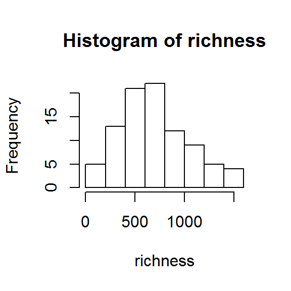

```r
#Plot richness
hist(richness)
```

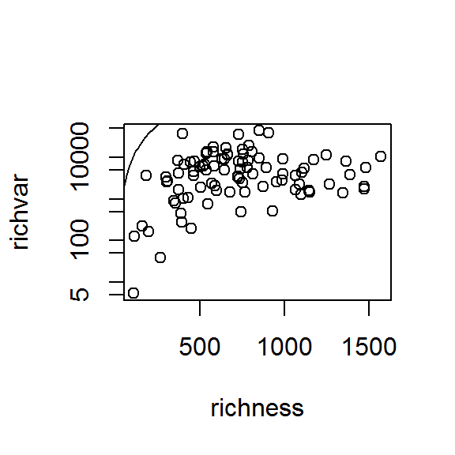

```r
#Calculate the variance for each sample
richvar<- apply(msbact, 1, var)
#Plot the dispersion
plot (richvar~richness, log='y')
curve(x^2, 0, 1000, add=TRUE)
```

```r
#Some overdispersion, but not as bad as the overall OTU overdispersion

#Linear regression on richness vs sequencing depth, to obtained detrended estimates
logrich<-log(richness)
corr1<-glm(logrich~depth, family=gaussian(link = identity))
summary(corr1)
```

```
##
## Call:
## glm(formula = logrich ~ depth, family = gaussian(link = identity))
##
## Deviance Residuals:
##      Min        1Q    Median        3Q       Max
## -1.18892  -0.27094   0.00233   0.29169   0.92154
##
## Coefficients:
##              Estimate Std. Error t value Pr(>|t|)
## (Intercept) 5.834e+00  1.038e-01  56.229  < 2e-16 ***
## depth       2.095e-05  3.157e-06   6.636 2.45e-09 ***
## ---
## Signif. codes:  0 '***' 0.001 '**' 0.01 '*' 0.05 '.' 0.1 ' ' 1
##
## (Dispersion parameter for gaussian family taken to be 0.2106002)
##
##     Null deviance: 28.016  on 90  degrees of freedom
## Residual deviance: 18.743  on 89  degrees of freedom
## AIC: 120.47
##
## Number of Fisher Scoring iterations: 2
```

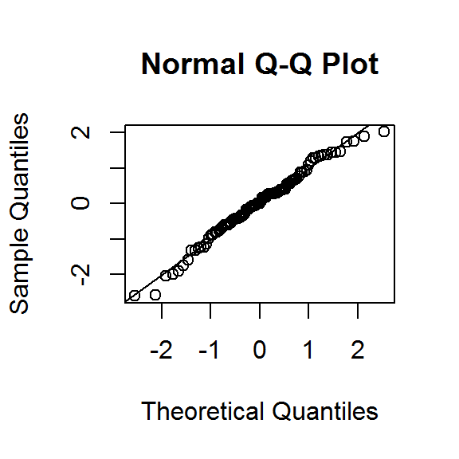

```r
sresid1<-(corr1$residuals-mean(corr1$residuals))/sd(corr1$residuals)
qqnorm(sresid1)
abline(0,1)
```

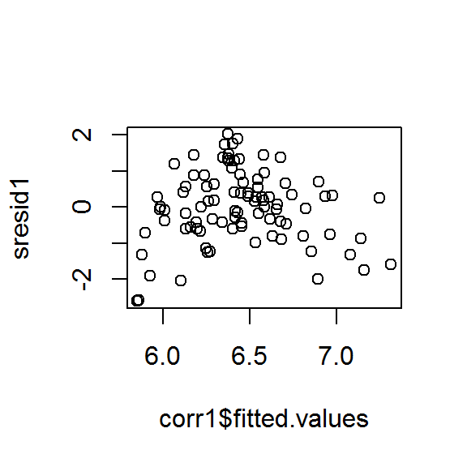

```r
plot(sresid1~corr1$fitted.values)
```

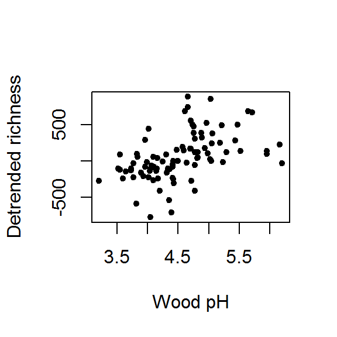

```r
#Creating back-transformed residuals
lrresid<-residuals(corr1, type = c("response"))
expfitted<-exp(corr1$fitted.values)
btresid<-richness - expfitted
#Heteroscedasticity seems to largely come from the absence of wood pH in the model
plot(btresid~metadat$Wood.pH, pch=20, xlab="Wood pH", ylab="Detrended richness")
```

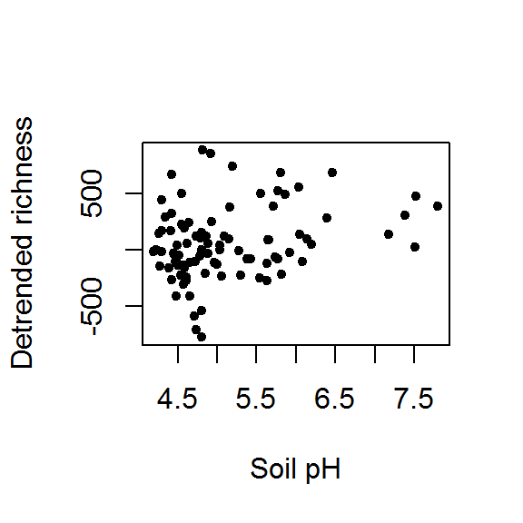

```r
plot(btresid~metadat$Soil.pH, pch=20, xlab="Soil pH", ylab="Detrended richness")
```

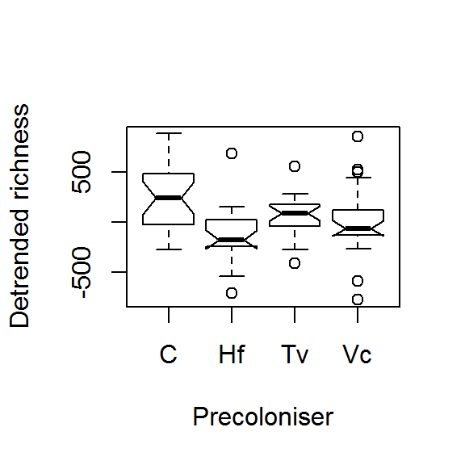

```r
plot(btresid~metadat$Precoloniser, xlab="Precoloniser", ylab="Detrended richness", notch=T)
```

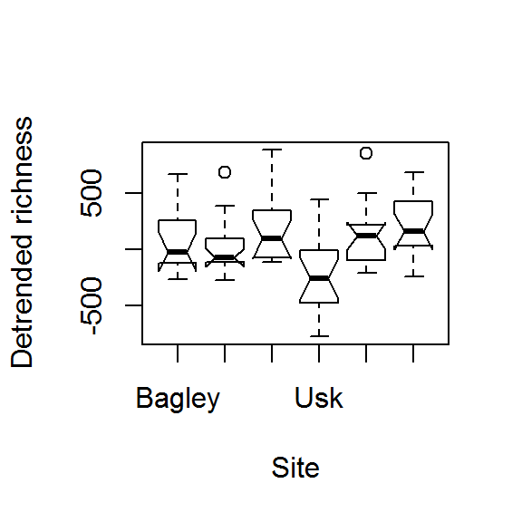

```r
plot(btresid~metadat$Site, xlab="Site", ylab="Detrended richness", notch=T)
```

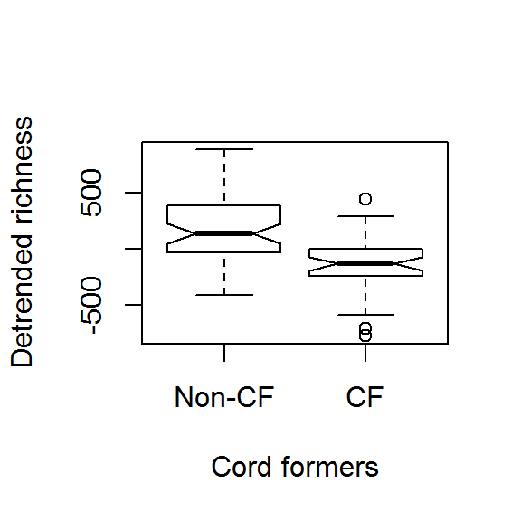

```r
plot(btresid~tops$cords, xlab="Cord formers", ylab="Detrended richness", notch=T)
```

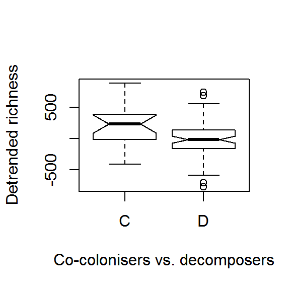

```r
plot(btresid~tops$decomp, xlab="Co-colonisers vs. decomposers", ylab="Detrended richness", notch=T)
```

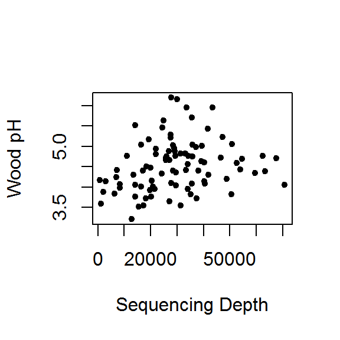

```r
#Plot wood pH against depth
plot(metadat$Wood.pH~depth, pch=20, xlab="Sequencing Depth", ylab="Wood pH")
points(metadat$Soil.pH[metadat$Site=="Wytham"], btresid[metadat$Site=="Wytham"], pch=20, col=rgb(red=255,blue=0,green=255,maxColorValue=255))
```

### Panelled graph of richness (Fig 6)

```r
pdf("sixway_richness.pdf")
{
par(mfrow=c(3,2), mar=c(5,5,1,1))
#Boxplot by precoloniser
plot(btresid~metadat$Precoloniser, xlab="Precoloniser", ylab="Detrended richness", notch=T)
mtext("(a)", side=3, adj=-0.2)
stripchart(btresid~metadat$Precoloniser,col="#000000",vertical = TRUE,pch=20,add=TRUE)
#Boxplot by site
plot(btresid~metadat$Site, xlab="Site", ylab="Detrended richness", xaxt="n", notch=T)
axis(side=1, at=c(1,2,3,4,5,6), labels = c("Bagley","Garth","Tintern","Usk","WS","Wytham"))
mtext("(b)", side=3, adj=-0.2)
stripchart(btresid~metadat$Site,col="#000000",vertical = TRUE,pch=20,add=TRUE)
#Plot by wood pH coloured by precoloniser
plot(btresid~metadat$Wood.pH, type="n", xlab="Wood pH", ylab="Detrended richness")
legend("topleft",  c("Control","Vc", "Tv", "Hf"), pch=c(20,20,20,20), bty="n", cex=0.8,
       col=c((rgb(red=0,blue=0,green=0,maxColorValue=255)),(rgb(red=0,blue=255,green=0,maxColorValue=255)),(rgb(red=0,blue=0,green=255,maxColorValue=255)),(rgb(red=255,blue=0,green=0,maxColorValue=255))))
mtext("(c)", side=3, adj=-0.2)
points(metadat$Wood.pH[metadat$Precoloniser=="C"], btresid[metadat$Precoloniser=="C"], pch=20, col=rgb(red=0,blue=0,green=0,maxColorValue=255))
points(metadat$Wood.pH[metadat$Precoloniser=="Vc"], btresid[metadat$Precoloniser=="Vc"], pch=20, col=rgb(red=0,blue=255,green=0,maxColorValue=255))
points(metadat$Wood.pH[metadat$Precoloniser=="Tv"], btresid[metadat$Precoloniser=="Tv"], pch=20, col=rgb(red=0,blue=0,green=255,maxColorValue=255))
points(metadat$Wood.pH[metadat$Precoloniser=="Hf"], btresid[metadat$Precoloniser=="Hf"], pch=20, col=rgb(red=255,blue=0,green=0,maxColorValue=255))
#Plot by soil pH coloured by site
plot(btresid~metadat$Soil.pH, type="n", xlab="Soil pH", ylab="Detrended richness", xaxt="n", xlim=c(3.25,7.75))
axis(side=1, at=c(3.5,4.0,4.5,5.0,5.5,6.0,6.5,7.0,7.5))
legend("topleft",  c("Bagley","Garth","Tintern","Usk","Wh'stone","Wytham"), pch=c(20,20,20,20), bty="n", cex=0.8,
       col=c((rgb(red=255,blue=0,green=0,maxColorValue=255)),(rgb(red=0,blue=255,green=0,maxColorValue=255)),(rgb(red=0,blue=0,green=255,maxColorValue=255)),
             (rgb(red=255,blue=255,green=0,maxColorValue=255)),(rgb(red=0,blue=255,green=255,maxColorValue=255)),(rgb(red=255,blue=0,green=200,maxColorValue=255))))
mtext("(d)", side=3, adj=-0.2)
points(metadat$Soil.pH[metadat$Site=="Bagley"], btresid[metadat$Site=="Bagley"], pch=20, col=rgb(red=255,blue=0,green=0,maxColorValue=255))
points(metadat$Soil.pH[metadat$Site=="Garth"], btresid[metadat$Site=="Garth"], pch=20, col=rgb(red=0,blue=255,green=0,maxColorValue=255))
points(metadat$Soil.pH[metadat$Site=="Tintern"], btresid[metadat$Site=="Tintern"], pch=20, col=rgb(red=0,blue=0,green=255,maxColorValue=255))
points(metadat$Soil.pH[metadat$Site=="Usk"], btresid[metadat$Site=="Usk"], pch=20, col=rgb(red=255,blue=255,green=0,maxColorValue=255))
points(metadat$Soil.pH[metadat$Site=="Whitestone"], btresid[metadat$Site=="Whitestone"], pch=20, col=rgb(red=0,blue=255,green=255,maxColorValue=255))
points(metadat$Soil.pH[metadat$Site=="Wytham"], btresid[metadat$Site=="Wytham"], pch=20, col=rgb(red=255,blue=0,green=200,maxColorValue=255))
#Plot by asco-basid split
plot(btresid~basidprop, type="n", xlab="Proportion Basidiomycota", ylab="Detrended richness", xlim=c(-0.07, 1.02), ylim=c(-750,875))
points(basidprop, btresid, pch=20, col=rgb(red=ascotransp,blue=basidtransp,green=0,maxColorValue=255))
legend("topleft",  c("Ascomycetes","Basidiomycetes"), pch=c(20,20), bty="n", cex=0.8,
       col=c((rgb(red=255,blue=0,green=0,maxColorValue=255)),(rgb(red=0,blue=255,green=0,maxColorValue=255))))
mtext("(e)", side=3, adj=-0.2)
#Boxplot by cord-formers
plot(btresid~tops$cords, xlab="Cord-forming", ylab="Detrended richness", notch=T)
mtext("(f)", side=3, adj=-0.2)
stripchart(btresid~tops$cords,col="#000000",vertical = TRUE,pch=20,add=TRUE)
}
dev.off()
```

### Modelling richness

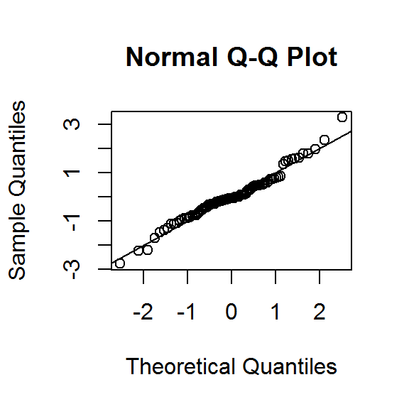

```r
richmod<-glm(logrich~depth + metadat$Precoloniser + metadat$Site + metadat$Soil.pH + metadat$Wood.pH,
             family=gaussian(link=identity))
rich.sresid<-(richmod$residuals-mean(richmod$residuals))/sd(richmod$residuals)
qqnorm(rich.sresid)
abline(0, 1)
```

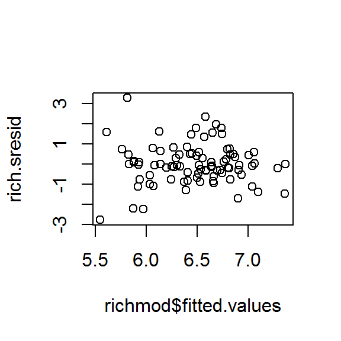

```r
plot(rich.sresid~richmod$fitted.values)
```

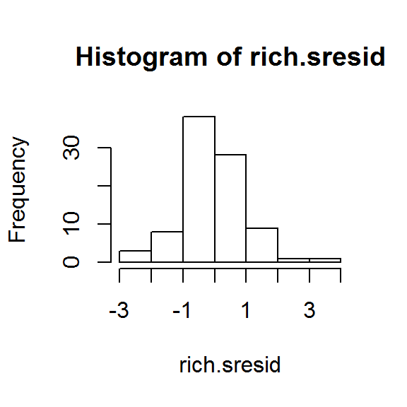

```r
hist(rich.sresid)
```

```r
summary(richmod)
```

```
##
## Call:
## glm(formula = logrich ~ depth + metadat$Precoloniser + metadat$Site +
##     metadat$Soil.pH + metadat$Wood.pH, family = gaussian(link = identity))
##
## Deviance Residuals:
##      Min        1Q    Median        3Q       Max
## -0.86600  -0.16943  -0.02003   0.15034   1.01857
##
## Coefficients:
##                          Estimate Std. Error t value Pr(>|t|)
## (Intercept)             4.119e+00  4.762e-01   8.648 6.30e-13 ***
## depth                   1.758e-05  2.678e-06   6.565 5.73e-09 ***
## metadat$PrecoloniserHf -2.542e-01  1.098e-01  -2.315   0.0233 *
## metadat$PrecoloniserTv -1.851e-01  1.020e-01  -1.814   0.0736 .
## metadat$PrecoloniserVc -1.103e-01  9.699e-02  -1.138   0.2588
## metadat$SiteGarth      -6.945e-02  1.753e-01  -0.396   0.6930
## metadat$SiteTintern     1.119e-01  1.382e-01   0.810   0.4206
## metadat$SiteUsk        -2.218e-01  1.381e-01  -1.606   0.1124
## metadat$SiteWhitestone  9.339e-02  1.322e-01   0.707   0.4820
## metadat$SiteWytham     -3.304e-02  2.152e-01  -0.154   0.8784
## metadat$Soil.pH         9.361e-02  8.436e-02   1.110   0.2707
## metadat$Wood.pH         3.326e-01  7.408e-02   4.490 2.50e-05 ***
## ---
## Signif. codes:  0 '***' 0.001 '**' 0.01 '*' 0.05 '.' 0.1 ' ' 1
##
## (Dispersion parameter for gaussian family taken to be 0.1104424)
##
##     Null deviance: 22.7953  on 87  degrees of freedom
## Residual deviance:  8.3936  on 76  degrees of freedom
##   (3 observations deleted due to missingness)
## AIC: 68.945
##
## Number of Fisher Scoring iterations: 2
```

```r
exp(richmod$coefficients) #gives the ratio of the group mean to that of the baseline
```

```
##            (Intercept)                  depth metadat$PrecoloniserHf
##             61.4824928              1.0000176              0.7755718
## metadat$PrecoloniserTv metadat$PrecoloniserVc      metadat$SiteGarth
##              0.8310478              0.8955238              0.9329050
##    metadat$SiteTintern        metadat$SiteUsk metadat$SiteWhitestone
##              1.1184412              0.8010557              1.0978857
##     metadat$SiteWytham        metadat$Soil.pH        metadat$Wood.pH
##              0.9674955              1.0981319              1.3946394
```

```r
#Save the coefficients for each precoloniser along with identifying information
coef<-richmod$coefficients[1:5]
precol<-rep("C", each=5)
site<-rep("Bagley", each=5)
modnames<-names(richmod$coefficients[1:5])


#Now repeat for the other levels
metadat$Precoloniser<-relevel(metadat$Precoloniser, ref="Vc")
#Re-run model
richmod<-glm(log(richness)~depth + metadat$Precoloniser + metadat$Site + metadat$Soil.pH + metadat$Wood.pH,
             family=gaussian(link=identity))
#Append new coefficients
coef<-append(coef, richmod$coefficients[1:5])
precol<-append(precol,(rep("Vc", each=5)))
site<-append(site,(rep("Bagley", each=5)))
modnames<-append(modnames,(names(richmod$coefficients[1:5])))

metadat$Precoloniser<-relevel(metadat$Precoloniser, ref="Tv")
richmod<-glm(log(richness)~depth + metadat$Precoloniser + metadat$Site + metadat$Soil.pH + metadat$Wood.pH,
             family=gaussian(link=identity))
coef<-append(coef, richmod$coefficients[1:5])
precol<-append(precol,(rep("Tv", each=5)))
site<-append(site,(rep("Bagley", each=5)))
modnames<-append(modnames,(names(richmod$coefficients[1:5])))

metadat$Precoloniser<-relevel(metadat$Precoloniser, ref="Hf")
richmod<-glm(log(richness)~depth + metadat$Precoloniser + metadat$Site + metadat$Soil.pH + metadat$Wood.pH,
             family=gaussian(link=identity))
coef<-append(coef, richmod$coefficients[1:5])
precol<-append(precol,(rep("Hf", each=5)))
site<-append(site,(rep("Bagley", each=5)))
modnames<-append(modnames,(names(richmod$coefficients[1:5])))

#Now do the same for site
coef<-append(coef, richmod$coefficients[6:10])
precol<-append(precol,(rep("Hf", each=5)))
site<-append(site,(rep("Bagley", each=5)))
modnames<-append(modnames,(names(richmod$coefficients[6:10])))

metadat$Site<-relevel(metadat$Site, ref="Garth")
richmod<-glm(log(richness)~depth + metadat$Precoloniser + metadat$Site + metadat$Soil.pH + metadat$Wood.pH,
             family=gaussian(link=identity))
coef<-append(coef, richmod$coefficients[6:10])
precol<-append(precol,(rep("Hf", each=5)))
site<-append(site,(rep("Garth", each=5)))
modnames<-append(modnames,(names(richmod$coefficients[6:10])))

metadat$Site<-relevel(metadat$Site, ref="Tintern")
richmod<-glm(log(richness)~depth + metadat$Precoloniser + metadat$Site + metadat$Soil.pH + metadat$Wood.pH,
             family=gaussian(link=identity))
coef<-append(coef, richmod$coefficients[6:10])
precol<-append(precol,(rep("Hf", each=5)))
site<-append(site,(rep("Tintern", each=5)))
modnames<-append(modnames,(names(richmod$coefficients[6:10])))

metadat$Site<-relevel(metadat$Site, ref="Usk")
richmod<-glm(log(richness)~depth + metadat$Precoloniser + metadat$Site + metadat$Soil.pH + metadat$Wood.pH,
             family=gaussian(link=identity))
coef<-append(coef, richmod$coefficients[6:10])
precol<-append(precol,(rep("Hf", each=5)))
site<-append(site,(rep("Usk", each=5)))
modnames<-append(modnames,(names(richmod$coefficients[6:10])))

metadat$Site<-relevel(metadat$Site, ref="Whitestone")
richmod<-glm(log(richness)~depth + metadat$Precoloniser + metadat$Site + metadat$Soil.pH + metadat$Wood.pH,
             family=gaussian(link=identity))
coef<-append(coef, richmod$coefficients[6:10])
precol<-append(precol,(rep("Hf", each=5)))
site<-append(site,(rep("Whitestone", each=5)))
modnames<-append(modnames,(names(richmod$coefficients[6:10])))

metadat$Site<-relevel(metadat$Site, ref="Wytham")
richmod<-glm(log(richness)~depth + metadat$Precoloniser + metadat$Site + metadat$Soil.pH + metadat$Wood.pH,
             family=gaussian(link=identity))
coef<-append(coef, richmod$coefficients[6:10])
precol<-append(precol,(rep("Hf", each=5)))
site<-append(site,(rep("Wytham", each=5)))
modnames<-append(modnames,(names(richmod$coefficients[6:10])))

#Return the levels to normal
metadat$Precoloniser<-relevel(metadat$Precoloniser, ref="C")
metadat$Site<-relevel(metadat$Site, ref="Bagley")

#Create a dataframe of the output
richoutput<-cbind.data.frame(modnames,coef,precol,site)
#Convert coefficients into ratios of geometric means
richoutput$ratios<-exp(richoutput$coef)
```

## Focus on taxa of interest

### Burkholderiaceae

```r
###Create a Burkholderiaceae subset
burk<-subset(msbact, select=(as.character(subset(taxbact$X.OTU.ID, taxbact$Family==" Burkholderiaceae"))))
all.equal(as.factor(row.names(burk)), metadat$X.SampleID, check.attributes = FALSE)
```

```
## [1] TRUE
```

```r
#Correct richness for sequencing depth
burkrich<-rowSums(burk > 0)
burkcorr<-glm(burkrich~depth, family=gaussian(link = identity))
summary(burkcorr)
```

```
##
## Call:
## glm(formula = burkrich ~ depth, family = gaussian(link = identity))
##
## Deviance Residuals:
##     Min       1Q   Median       3Q      Max
## -31.543  -11.904   -1.356   12.740   45.358
##
## Coefficients:
##              Estimate Std. Error t value Pr(>|t|)
## (Intercept) 2.027e+01  3.674e+00   5.516 3.36e-07 ***
## depth       4.806e-04  1.118e-04   4.298 4.39e-05 ***
## ---
## Signif. codes:  0 '***' 0.001 '**' 0.01 '*' 0.05 '.' 0.1 ' ' 1
##
## (Dispersion parameter for gaussian family taken to be 264.1279)
##
##     Null deviance: 28388  on 90  degrees of freedom
## Residual deviance: 23507  on 89  degrees of freedom
## AIC: 769.68
##
## Number of Fisher Scoring iterations: 2
```

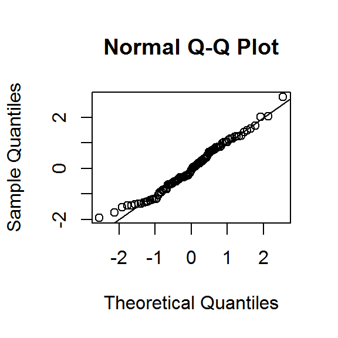

```r
burksresid1<-(burkcorr$residuals-mean(burkcorr$residuals))/sd(burkcorr$residuals)
qqnorm(burksresid1)
abline(0,1)
```

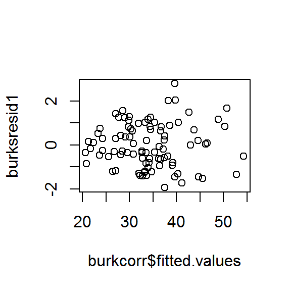

```r
plot(burksresid1~burkcorr$fitted.values)
```

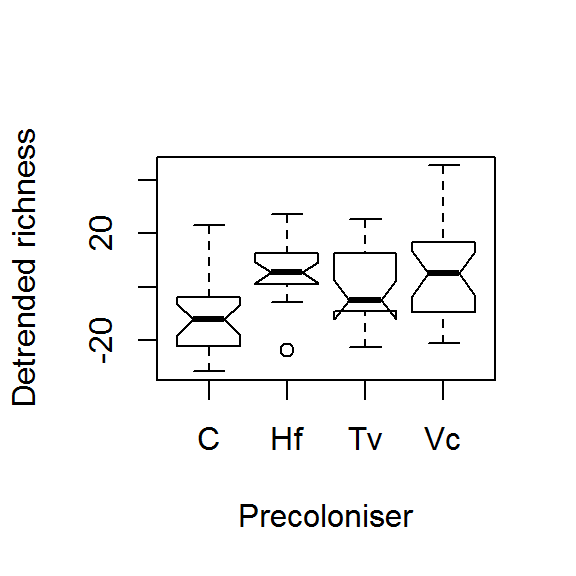

```r
corrected.burk<-residuals(burkcorr, type = c("response"))

#Plotting
boxplot(corrected.burk~metadat$Precoloniser, notch=TRUE,
        xlab="Precoloniser", ylab="Detrended richness")
```

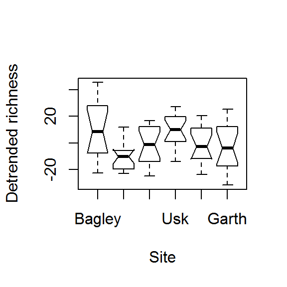

```r
boxplot(corrected.burk~metadat$Site, notch=TRUE,
        xlab="Site", ylab="Detrended richness")
```

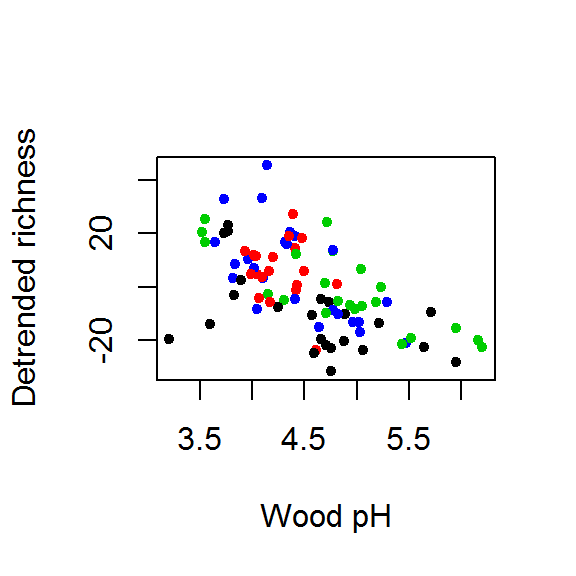

```r
plot(corrected.burk~metadat$Wood.pH, col=metadat$Precoloniser, pch=20,
     xlab="Wood pH", ylab="Detrended richness")
```

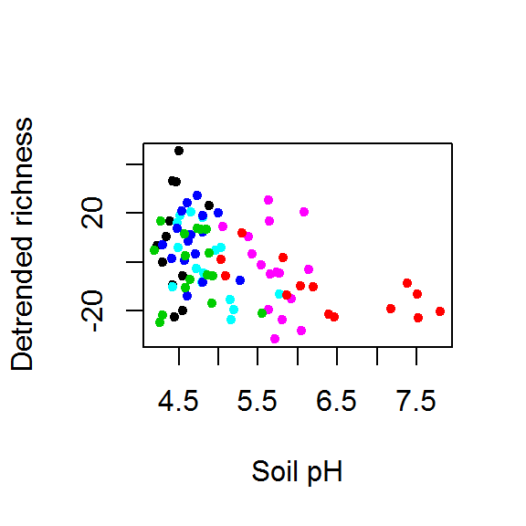

```r
plot(corrected.burk~metadat$Soil.pH, col=metadat$Site, pch=20,
     xlab="Soil pH", ylab="Detrended richness")
```

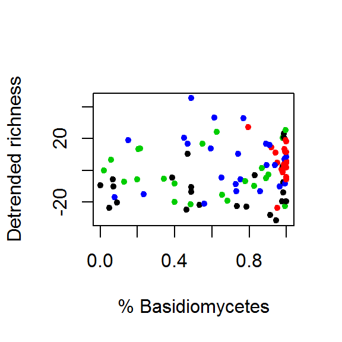

```r
plot(corrected.burk~basidprop, col=metadat$Precoloniser, pch=20,
     xlab="% Basidiomycetes", ylab="Detrended richness")
```

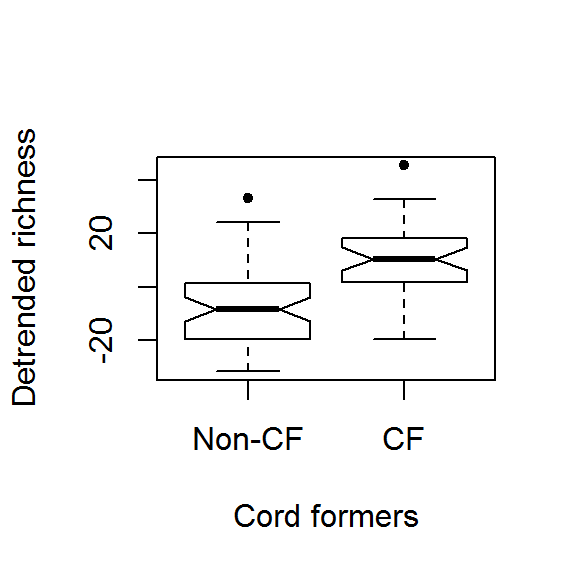

```r
plot(corrected.burk~tops$cords, pch=20, notch=TRUE,
     xlab="Cord formers", ylab="Detrended richness")
```